## Using the waterNETN R package

### Getting started

#### Installation

#### **Step 1.** Install R, RStudio, and RTools in Software Center

#### **Step 2.** Install devtools package in R:

```r
install.packages('devtools')
```

#### **Step 3.** Install waterNETN from github

Note that whenever the `waterNETN` package is updated, you can rerun this code to install the latest version.

```r
library(devtools)
install_github("KateMMiller/waterNETN")
```

#### **Step 4.** Load waterNETN R package

```r
library(waterNETN)
```

#### **Step 5.** Import data

Note that R is not able to connect to files on Sharepoint or MS Teams (b/c Teams also stores all files on Sharepoint). That means you need to store data package files on your local machine or on a server (e.g. NETN Z drive). The default option for importing data will add the data package views (i.e., flatfiles) to an environment called VIEWS_WQ to your Environment work space (i.e. Environtment tab in top right panel). If you would rather import each individual view into your R session, specify with the new_env argument (e.g., `importData(new_env = F)`).

**Option 1.** Import data via .csv files. The file path should be where csvs are on your machine or server.

```r
importData(type = 'csv',
           filepath = "C:/NETN/R_Dev/Water/data") # update filepath to your computer
```

**Option 2.** Import data via zip file of csvs. The filepath should be the location and name of the zip file.

```r
importData(type = 'zip',
           filepath = "C:/NETN/R_Dev/Water/data/NETN_Water_Data_Package_20240423.zip")
```

**Option 3.** Import data via data package database file on your computer

```r
importData(type = 'dbfile',
           filepath = "C:/NETN/R_Dev/Water/data/NETN_h3Ov4_DataPackage_202331115.accdb")
```

**Option 4.** Import data via data package database DSN (Data Source Name) on your computer. Note that this is the default setting. As long as you have a named DSN called “NETNWQ_DP” that links to the data package database, and that database links to the latest NETN WQ backend database, the code below will run. See *Setting up DSN* tab for how to set up DSN.

```r
importData() # easiest
importData(type = 'DSN', odbc = "NETNWQ_DP") # equivalent to line above
```

#### **Step 6.** (Optional) Export data package to zip

You can export all of the csvs to a zip file with the day’s date stamped on the file name. This allows you to import the tables from the database, then export the csvs as one zip file.

```r
importData() # easiest
exportData(filepath = "./data", zip = TRUE)
```

#### **Step 7. Play with the data**

The functions in the `waterNETN` package are designed to work with the views, and are the best way to interact with the data to query by park, site, site type, year, parameter, etc. However, if you want to view the raw data, and you imported the data into the VIEWS_WQ environment, you can access them with the code below:

```r
# See list of the views
names(VIEWS_WQ)

# View one of the views
View(VIEWS_WQ$Chemistry_Data)

# Assign a view to a data frame named chem in R. Interact with chem the way you would work with any normal data frame in R.
chem <- VIEWS_WQ$Chemistry_Data
```

If you want to use the `print_head()` function that shows output in the markdown, run the code below. This makes the results print cleaner in the markdown report. For your purposes, you can just run: `head(dataframe)`.

```r
print_head <- function(df){
  knitr::kable(df[1:6,]) |> #, table.attr = "style='width:60%;'") |>
    kableExtra::kable_classic(full_width = F, font_size = 12,
                              bootstrap_options = c("condensed"))
}
```

#### Getting help

#### **Getting (and improving) help**

The functions in `waterNETN` have help documentation like any R package. To view the help, you can go to the Packages tab and click on waterNETN (see below). That will show you all the functions in the package. Clicking on individual functions will take you to the help documentation for that function.

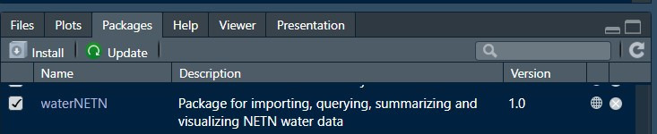

You can also see the help of a function by running, for example:

```r
?importData
```

If `waterNETN` isn’t loaded yet, you’d run:

```r
?waterNETN::importData
```

Each function’s help includes a Description, Usage (i.e. function arguments and their defaults), Argument options/definitions, and several examples showing how the function can be used.

**This is where you come in! If you notice typos or can think of better descriptions, examples, error messages, etc., please send them my way!** After we’re more comfortable with R packages and get versed on GitHub, you’ll be able to make those changes directly in the package. For now, you can just send me your suggestions and I’ll make the changes.

Finally, if you ever want to peak under the hood at the function, you can view it several ways.

1. Keep F2 key pressed and click on the function name in R. This trick works for many but not all functions in R.
2. View code in the [GitHub katemmiller/waterNETN repo](https://github.com/KateMMiller/waterNETN/tree/main). The functions are in the R folder.

#### Setting up DSN

#### **Setting up a DSN**

1. Go to Windows Start Menu and search ODBC. Click on ODBC Data Sources (64-bit)

[figure not shown]

2. Click on *Add*, then select *Microsoft Access Driver (*.mdb, *.accdb)* then click *Finish* in next menu.

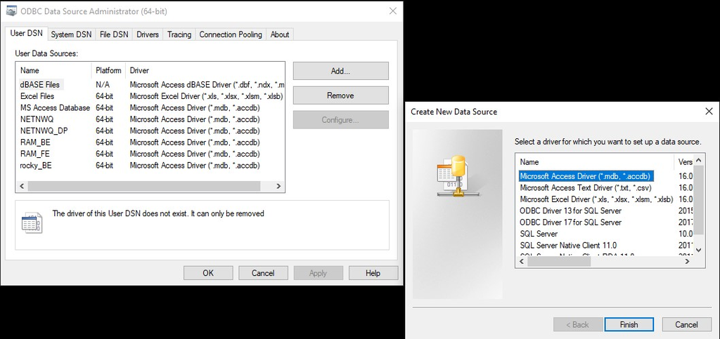

3. Enter **NETNWQ_DP** into the Data Source Name (red arrow), click on Select (red circle). In new window, click on C:/ (orange arrow) and find the path to your database. If it’s on the Z drive, then click on the Drives window and select correct Drive. Click on the data package database (yellow arrow). When complete, click OK. Finally, add the name of the database file to the Description (blue arrow), so it’s easier to check whether you’re using the latest version.

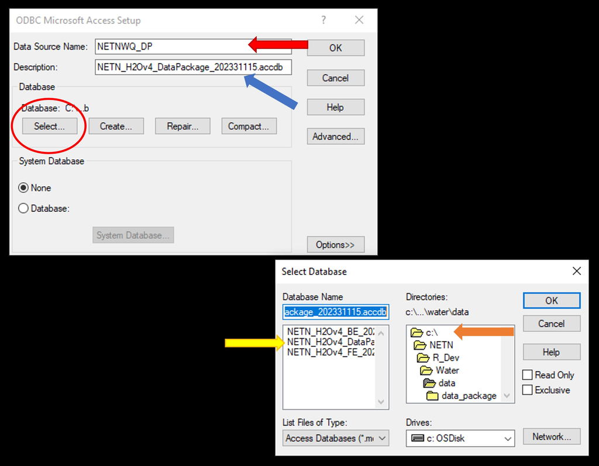

4. If updating an existing DSN, follow similar process, except click on the DSN in the first window and select *Configure* instead of Add.

### Climate Functions

#### Daymet

Daymet data are 1km gridded daily climate data, similar to PRISM data, but with more daily data associated with each location and more efficient downloading process (extract data from lat/long points, rather than download nationwide raster files and extract manually). Daymet data go back to 1980. See https://daymet.ornl.gov/ for more information. Another benefit of Daymet over PRISM is the data can be used to calculate drought indices, like Standardized Precipitation-Evapotranspiration Index (SPEI). Note: I’ll eventually add SPEI metrics to the output of this function.

Daymet data are typically available for a calendar year a a few months into the next year.

In waterNETN, you can download Daymet data by park, site, site type, and spanning years 1980 to 2023. See examples below. The larger the number of sites and years, the longer it can take. I added the option to save the data as a csv to disk via `export = T` and specifying a `filepath`, so you don’t have to download these data over and over. I’ll make it possible to read csvs into R to work with climate summary and plotting functions.

The following code downloads Daymet data for East Primrose Brook in MORR for the entire monitoring period, and exports to a data folder in the working directory.

```r
prim <- getClimDaymet(site = "MORRSB", years = 2006:2023, export = T,
                      filepath = "./data")
print_head(prim) # table of first 6 rows- this is a custom function I wrote to save on coding
```

| SiteCode | dm_tile | SiteLatitude | SiteLongitude | altitude | Date | year | yday | dm_dayl_s | dm_prcp_mmday | dm_srad_Wm2 | dm_swe_kgm2 | dm_tmax_degc | dm_tmin_degc | dm_vp_Pa |
| --- | --- | --- | --- | --- | --- | --- | --- | --- | --- | --- | --- | --- | --- | --- |
| MORRSB | 11753 | 40.76506 | -74.52978 | 170 | 2006-01-02 | 2006 | 1 | 32891.95 | 0.00 | 163.10 | 0 | 4.53 | -3.54 | 470.25 |
| MORRSB | 11753 | 40.76506 | -74.52978 | 170 | 2006-01-03 | 2006 | 2 | 32934.47 | 26.22 | 124.24 | 0 | 5.82 | -2.49 | 508.61 |
| MORRSB | 11753 | 40.76506 | -74.52978 | 170 | 2006-01-04 | 2006 | 3 | 32980.46 | 17.43 | 51.33 | 0 | 2.29 | -0.77 | 577.46 |
| MORRSB | 11753 | 40.76506 | -74.52978 | 170 | 2006-01-05 | 2006 | 4 | 33029.90 | 2.03 | 117.57 | 0 | 3.93 | -3.69 | 465.09 |
| MORRSB | 11753 | 40.76506 | -74.52978 | 170 | 2006-01-06 | 2006 | 5 | 33082.75 | 0.00 | 189.95 | 0 | 7.90 | -1.83 | 534.07 |
| MORRSB | 11753 | 40.76506 | -74.52978 | 170 | 2006-01-07 | 2006 | 6 | 33138.96 | 0.00 | 113.99 | 0 | 4.03 | -1.24 | 557.73 |

The following code downloads Daymet data for all sites in MABI for 2023. Results are assigned to R session environment and not exported to data folder in the working directory.

```r
# Daymet data for the Pogue and Pogue stream for 2023, but not exporting to disk.
mabi_dm <- getClimDaymet(park = "MABI", years = 2023)
print_head(mabi_dm)
```

| SiteCode | dm_tile | SiteLatitude | SiteLongitude | altitude | Date | year | yday | dm_dayl_s | dm_prcp_mmday | dm_srad_Wm2 | dm_swe_kgm2 | dm_tmax_degc | dm_tmin_degc | dm_vp_Pa |
| --- | --- | --- | --- | --- | --- | --- | --- | --- | --- | --- | --- | --- | --- | --- |
| MABISA | 11934 | 43.63493 | -72.52937 | 302 | 2023-01-02 | 2023 | 1 | 31737.91 | 0.00 | 166.06 | 0 | 7.88 | 0.32 | 624.97 |
| MABISA | 11934 | 43.63493 | -72.52937 | 302 | 2023-01-03 | 2023 | 2 | 31785.76 | 0.00 | 169.12 | 0 | 6.08 | -1.57 | 544.55 |
| MABISA | 11934 | 43.63493 | -72.52937 | 302 | 2023-01-04 | 2023 | 3 | 31837.50 | 5.54 | 105.08 | 0 | 2.20 | -3.49 | 472.10 |
| MABISA | 11934 | 43.63493 | -72.52937 | 302 | 2023-01-05 | 2023 | 4 | 31893.11 | 11.65 | 110.11 | 0 | 4.30 | -1.77 | 536.58 |
| MABISA | 11934 | 43.63493 | -72.52937 | 302 | 2023-01-06 | 2023 | 5 | 31952.54 | 2.13 | 71.89 | 0 | 4.10 | 0.43 | 630.18 |
| MABISA | 11934 | 43.63493 | -72.52937 | 302 | 2023-01-07 | 2023 | 6 | 32015.75 | 4.29 | 45.28 | 0 | 2.27 | 0.09 | 614.84 |

#### Weather Station

For each NETN monitoring site, I used the `rnoaa` package to find all weather stations within 20km radius of each site’s lat/long coordinates. I then checked the period of record for each of these sites. I selected the closest weather station with the longest period of record that included 2023 and 2024. This assessment was done at the park level, so the data for each site within a park is the same. The API used to download weather station data is data.rcc-acis.org. Unfortunately only temperature data are available for ACAD’s McFarland Hill weather station (AKA MARS). ACAD’s hourly precipitation data were downloaded separately from the NADP website http://nadp2.slh.wisc.edu/siteOps/ppt/. These data only go back to 2008 and were aggregated to daily total precipitation. This function is slower for ACAD as a result. Though note that data are downloaded at the park level, then joined with site-specific data. In other words, data are downloaded for a park x combination of years once, then joined to site-level data. Weather stations used and their distance from each site are included in the output.

The following code downloads weather station data for all sites in ROVA the past 10 years and writes to a csv.

```r
rova_ws <- getClimWStat(park = "ROVA", years = 2013:2023, export = T,
                        filepath = "./data")
print_head(rova_ws)
```

| SiteCode | SiteName | UnitCode | Date | year | month | doy | ws_id | ws_lat | ws_long | ws_dist_km | ws_tmaxc | ws_tminc | ws_pcpmm |
| --- | --- | --- | --- | --- | --- | --- | --- | --- | --- | --- | --- | --- | --- |
| ROVASA | Lower FDR Brook | ROVA | 2013-01-01 | 2013 | 1 | 1 | USW00064756 | 41.7858 | -73.7422 | 16.564 | 1.667 | -10.000 | 0.000 |
| ROVASA | Lower FDR Brook | ROVA | 2013-01-02 | 2013 | 1 | 2 | USW00064756 | 41.7858 | -73.7422 | 16.564 | -1.667 | -17.222 | 0.000 |
| ROVASA | Lower FDR Brook | ROVA | 2013-01-03 | 2013 | 1 | 3 | USW00064756 | 41.7858 | -73.7422 | 16.564 | -5.000 | -18.333 | 0.000 |
| ROVASA | Lower FDR Brook | ROVA | 2013-01-04 | 2013 | 1 | 4 | USW00064756 | 41.7858 | -73.7422 | 16.564 | 2.778 | -6.667 | 0.000 |
| ROVASA | Lower FDR Brook | ROVA | 2013-01-05 | 2013 | 1 | 5 | USW00064756 | 41.7858 | -73.7422 | 16.564 | 3.889 | -6.667 | 0.000 |
| ROVASA | Lower FDR Brook | ROVA | 2013-01-06 | 2013 | 1 | 6 | USW00064756 | 41.7858 | -73.7422 | 16.564 | 5.000 | -5.556 | 0.254 |

The following code downloads weather station data for all lakes in ACAD in 2023, but doesn’t export to disk.

```r
acad_ws <- getClimWStat(park = "ACAD", site_type = "lake", years = 2023)
print_head(acad_ws)
```

| SiteCode | SiteName | UnitCode | Date | year | month | doy | ws_id | ws_lat | ws_long | ws_dist_km | ws_tmaxc | ws_tminc | ws_pcpmm |
| --- | --- | --- | --- | --- | --- | --- | --- | --- | --- | --- | --- | --- | --- |
| ACANTB | Aunt Bettys Pond | ACAD | 2023-01-01 | 2023 | 1 | 1 | USR0000MMCF | 44.3769 | -68.2608 | 1.319 | 11.667 | 1.111 | 0.000 |
| ACANTB | Aunt Bettys Pond | ACAD | 2023-01-02 | 2023 | 1 | 2 | USR0000MMCF | 44.3769 | -68.2608 | 1.319 | 6.667 | 0.000 | 0.000 |
| ACANTB | Aunt Bettys Pond | ACAD | 2023-01-03 | 2023 | 1 | 3 | USR0000MMCF | 44.3769 | -68.2608 | 1.319 | 5.556 | 1.111 | 3.556 |
| ACANTB | Aunt Bettys Pond | ACAD | 2023-01-04 | 2023 | 1 | 4 | USR0000MMCF | 44.3769 | -68.2608 | 1.319 | 5.556 | -0.556 | 4.064 |
| ACANTB | Aunt Bettys Pond | ACAD | 2023-01-05 | 2023 | 1 | 5 | USR0000MMCF | 44.3769 | -68.2608 | 1.319 | -0.556 | -2.778 | 5.588 |
| ACANTB | Aunt Bettys Pond | ACAD | 2023-01-06 | 2023 | 1 | 6 | USR0000MMCF | 44.3769 | -68.2608 | 1.319 | -1.111 | -2.778 | 3.556 |

### get Data Functions

#### getSites()

##### getSites()

Query site-level data. This function combines columns in common between the Sites_Stream and Sites_Lake views. This is a good building block for other functions, but may be less helpful on its own. Though, one helpful use of this function is to get the site codes for a given park or site.

Get site info for ACAD lakes

```r
ACAD_lakes <- getSites(park = "ACAD", site_type = "lake")
```

Get site info for the Pogue

```r
pogue <- getSites(site = "MABIPA")
```

List site codes and their full site name for SARA

```r
sara_sites <- getSites(park = "SARA") |> select(SiteCode, SiteName)
print_head(sara_sites)
```

|  | SiteCode | SiteName |
| --- | --- | --- |
| 1 | SARASA | Kroma Kill |
| 2 | SARASC | Upper Mill Creek |
| 3 | SARASD | Mill Creek Confluence |
| NA | NA | NA |
| NA.1 | NA | NA |
| NA.2 | NA | NA |

##### getSitesLake()

Query site-level data for lakes only. This returns lake-only columns in the Sites_Lake views

Get site info for ACAD lakes

```r
ACAD_str <- getSitesLake(park = "ACAD")
print_head(ACAD_str)
```

| SiteCode | SiteName | UnitCode | SubUnitCode | HUC12 | ContribWshedArea_km2 | Inlet | Outlet | MaxDepth_m | TrophicType | LegislativeClass | FishMgtType | SiteDescription | Notes |
| --- | --- | --- | --- | --- | --- | --- | --- | --- | --- | --- | --- | --- | --- |
| ACANTB | Aunt Bettys Pond | ACAD | NA | 10500021502 | 2.77 | unnamed | RICHARDSON BRK | 2.1 | EUTROPHIC | GPA | COLDWATER | Shallow, marshy pond with an area of 31.5 acres. Inlet: Aunt Betty Inlet. Outlet: Richardson Brook. | Pond is full of emergent vegetation by mid-summer. Deep hole is in NE corner, near outlet. Surrounded by ANP. Last surveyed by IFW in 1982. Closed to ice fishing. |
| ACBOWL | The Bowl | ACAD | NA | 10500021501 | 0.21 | NA | OTTER CREEK | 9.0 | MESOTROPHIC | GPA | NONE | High elevation, mesotrophic pond located between Cahamplaine Mtn. and The Beehive. | Located off the Beehive Trail. Fish survey conducted in 1995 BY J.R. Burgess. Not monitored by NETN- sampled annually for acid depositon effects by ACAD staff. Once served as water supply for Satterle… |
| ACBRBK | Bear Brook Pond | ACAD | NA | 10500021501 | NA | BEAR BROOK | BEAR BROOK | 3.9 | MESOTROPHIC | GPA | NONE | Mesotrophic, unstratified pond with an area of 7.5 acres. Its inlet and outlet is Bear Brook. | Located on Park Loop Road near Jackson Lab. Site of ANP purple loosestrife monitoring/control plots. Active beaver in area. Fish survey in 1995 by J.R. Burgess. Also known as Beaver Dam Pond. |
| ACBUBL | Bubble Pond | ACAD | NA | 10500021501 | 1.77 | unnamed | BUBBLE BROOK | 11.9 | MESOTROPHIC | GPA | COLDWATER | Oligotrophic, stratified lake with an area of 33 acres. Part of the public water supply. Inlet: unnamed stream on southern end. Outlet: Bubble Brook. | Surrounded by ANP. Connects with Bar Harbor water supply. Last surveyed by IFW in 1942. Closed to ice fishing. |
| ACEAGL | Eagle Lake | ACAD | NA | 10500021501 | 5.60 | BUBBLE BROOK | DUCK BROOK | 33.5 | OLIGOTROPHIC | GPA | COLDWATER | Oligotrophic, stratified lake with an area of 465.8 acres. Part of the public water supply. Inlet: Bubble Brook. Outlet: Duck Brook. | LLS spawning area built in outlet in 55. 10 hp outboard limit. Last surveyed by IFW in 1990. Surrounded by ANP. |
| ACECHO | Echo Lake | ACAD | NA | 10500021502 | 5.10 | LURVEY SPRG BRK | DENNING BROOK | 20.1 | OLIGOTROPHIC | GPA | COLDWATER | Oligotrophic, stratified lake with an area of 236.8 acres. Inlet: Lurvey Spring Brook. Outlet: Denning Brook. | Partial boundary w/ANP. Last surveyed by IFW in 1988. Outboard hp restrictions. Reclaimed in 1956. Guarded ANP swim beach on south end. |

Get all site info for the Pogue Pond

```r
pogue <- getSitesLake(site = "MABIPA", output = 'verbose')
print_head(pogue)
```

|  | GroupCode | GroupName | UnitCode | UnitName | SubUnitCode | SubUnitName | SiteCode | SiteName | SiteLatitude | SiteLongitude | Datum | XYAccuracy | HUC12 | ContribWshedArea_km2 | Inlet | Outlet | MaxDepth_m | TrophicType | LegislativeClass | FishMgtType | SiteDescription | Notes | IsPointCUI |
| --- | --- | --- | --- | --- | --- | --- | --- | --- | --- | --- | --- | --- | --- | --- | --- | --- | --- | --- | --- | --- | --- | --- | --- |
| 1 | NETN | Northeast Temperate Network | MABI | Marsh-Billings-Rockefeller National Historical Park | NA | NA | MABIPA | The Pogue | 43.63336 | -72.54263 | NAD83 | NA | 10801060206 | 0.57 | NA | Pogue Brk | 3.4 | MESOTROPHIC | A(1) | COLDWATER | The Pogue is a 14-acre pond at the headwaters of the Pogue Brook. Naturally a spring-fed boggy area, it was created in the 1880s with an earthen dam. Swimming, fishing, or wading is prohibited. |  | FALSE |
| NA | NA | NA | NA | NA | NA | NA | NA | NA | NA | NA | NA | NA | NA | NA | NA | NA | NA | NA | NA | NA | NA | NA | NA |
| NA.1 | NA | NA | NA | NA | NA | NA | NA | NA | NA | NA | NA | NA | NA | NA | NA | NA | NA | NA | NA | NA | NA | NA | NA |
| NA.2 | NA | NA | NA | NA | NA | NA | NA | NA | NA | NA | NA | NA | NA | NA | NA | NA | NA | NA | NA | NA | NA | NA | NA |
| NA.3 | NA | NA | NA | NA | NA | NA | NA | NA | NA | NA | NA | NA | NA | NA | NA | NA | NA | NA | NA | NA | NA | NA | NA |
| NA.4 | NA | NA | NA | NA | NA | NA | NA | NA | NA | NA | NA | NA | NA | NA | NA | NA | NA | NA | NA | NA | NA | NA | NA |

##### getSitesStream()

Query site-level data for streams only. This returns stream-only columns in the Sites_Stream views

Get site info for ACAD streams

```r
ACAD_str <- getSitesStream(park = "ACAD")
print_head(ACAD_str)
```

| SiteCode | UnitCode | SubUnitCode | USGS_StaNumb | ContribWshedArea_km2 | SiteDescription | Notes | LegislativeClass | FisheryType |
| --- | --- | --- | --- | --- | --- | --- | --- | --- |
| ACABIN | ACAD | NA | 1022869 | 2.4802373 | The inlet flows north from Gilmore Meadow into Aunt Betty Pond. | Beavers often present both US & DS of carriage road. | AA | Warmwater |
| ACBRKB | ACAD | NA | 1022825 | 3.7293399 | The stream flows north from the Breakneck Ponds and into the ocean (Hulls Cove). | Exact sampling point can vary depending on streamflow/water level. Hits baseflow in dry years. | AA | Coldwater |
| ACBRWN | ACAD | NA | 1022866 | 1.1840292 | The stream flows northwest from Parkman Mountain into the ocean (Somes Sound). Measure east (US) of culvert under Sargent Drive. | Very close to municipal sand/salt storage facility. | AA | Coldwater |
| ACCADS | ACAD | NA | 1022835 | 0.6223256 | On right bank approximately 500 feet upstream of the crossing of Canon Brook Trail (500 ft upstream from confluence with Otter Creek and 0.5 miles southeast of Cadillac summit) | High-elevation stream flows south on the east face of Cadillac mountain into Canon Brook- Otter Creek. Former site of USGS stream gage 01022835 (1999- 2006). | AA | Coldwater |
| ACDKLI | ACAD | NA | 10228755 | 0.4818996 | The stream flows north from Duck Pond into Long Pond (MDI). | Can be near or at baseflow in dry years and difficult to measure streamflow. | AA | Coldwater |
| ACDUCK | ACAD | NA | 1022827 | 9.6264998 | Sample site is located north of Rte. 233 crossing, approx. 200 ft. DS of culvert. | Duck Brook flows north from Eagle Lake into the ocean (Hulls Cove/Frenchman Bay). Established in 2009, replaces ACEGLO. | AA | Coldwater |

Get all site info for the Pogue Stream

```r
poguestr <- getSitesStream(site = "MABISA", output = 'verbose')
print_head(poguestr)
```

|  | GroupCode | GroupName | UnitCode | UnitName | SubUnitCode | SubUnitName | SiteCode | SiteName | SiteLatitude | SiteLongitude | Datum | XYAccuracy | USGS_StaNumb | ContribWshedArea_km2 | SiteDescription | Notes | LegislativeClass | FisheryType | IsPointCUI |
| --- | --- | --- | --- | --- | --- | --- | --- | --- | --- | --- | --- | --- | --- | --- | --- | --- | --- | --- | --- |
| 1 | NETN | Northeast Temperate Network | MABI | Marsh-Billings-Rockefeller National Historical Park | NA | NA | MABISA | Pogue Brook | 43.63493 | -72.52937 | NAD83 | NA | NA | 0.9945554 | Only stream within the park, the outlet of The Pogue. One stream-sampling site was selected to represent Pogue Brook. This site was chosen because it is the most downstream location within park bounda… |  | A(1) | Coldwater | FALSE |
| NA | NA | NA | NA | NA | NA | NA | NA | NA | NA | NA | NA | NA | NA | NA | NA | NA | NA | NA | NA |
| NA.1 | NA | NA | NA | NA | NA | NA | NA | NA | NA | NA | NA | NA | NA | NA | NA | NA | NA | NA | NA |
| NA.2 | NA | NA | NA | NA | NA | NA | NA | NA | NA | NA | NA | NA | NA | NA | NA | NA | NA | NA | NA |
| NA.3 | NA | NA | NA | NA | NA | NA | NA | NA | NA | NA | NA | NA | NA | NA | NA | NA | NA | NA | NA |
| NA.4 | NA | NA | NA | NA | NA | NA | NA | NA | NA | NA | NA | NA | NA | NA | NA | NA | NA | NA | NA |

#### getEvents()

Query water data by park, site, site_type, year and month.

Get event info for Witch Hole Pond in ACAD in 2023

```r
ACAD_lakes <- getEvents(site = "ACWHOL", years = 2023)
print_head(ACAD_lakes)
```

| UnitCode | SiteCode | SiteName | SiteType | SiteLatitude | SiteLongitude | EventDate | EventCode | year | month | doy |
| --- | --- | --- | --- | --- | --- | --- | --- | --- | --- | --- |
| ACAD | ACWHOL | Witch Hole Pond | Lake | 44.40001 | -68.24295 | 2023-05-03 | 4649 | 2023 | 5 | 122 |
| ACAD | ACWHOL | Witch Hole Pond | Lake | 44.40001 | -68.24295 | 2023-05-17 | 4652 | 2023 | 5 | 136 |
| ACAD | ACWHOL | Witch Hole Pond | Lake | 44.40001 | -68.24295 | 2023-06-26 | 4698 | 2023 | 6 | 176 |
| ACAD | ACWHOL | Witch Hole Pond | Lake | 44.40001 | -68.24295 | 2023-07-26 | 4741 | 2023 | 7 | 206 |
| ACAD | ACWHOL | Witch Hole Pond | Lake | 44.40001 | -68.24295 | 2023-08-21 | 4782 | 2023 | 8 | 232 |
| ACAD | ACWHOL | Witch Hole Pond | Lake | 44.40001 | -68.24295 | 2023-09-18 | 4818 | 2023 | 9 | 260 |

Get event info for all years in the Pogue

```r
pogue <- getEvents(site = "MABIPA", years = 2006:2023)
print_head(pogue)
```

| UnitCode | SiteCode | SiteName | SiteType | SiteLatitude | SiteLongitude | EventDate | EventCode | year | month | doy |
| --- | --- | --- | --- | --- | --- | --- | --- | --- | --- | --- |
| MABI | MABIPA | The Pogue | Lake | 43.63336 | -72.54263 | 2006-06-13 | 1330 | 2006 | 6 | 163 |
| MABI | MABIPA | The Pogue | Lake | 43.63336 | -72.54263 | 2006-07-20 | 671 | 2006 | 7 | 200 |
| MABI | MABIPA | The Pogue | Lake | 43.63336 | -72.54263 | 2006-08-23 | 1331 | 2006 | 8 | 234 |
| MABI | MABIPA | The Pogue | Lake | 43.63336 | -72.54263 | 2006-09-13 | 1054 | 2006 | 9 | 255 |
| MABI | MABIPA | The Pogue | Lake | 43.63336 | -72.54263 | 2006-10-11 | 1055 | 2006 | 10 | 283 |
| MABI | MABIPA | The Pogue | Lake | 43.63336 | -72.54263 | 2007-05-08 | 1057 | 2007 | 5 | 127 |

Get date of sampling each site in lower NETN in May, 2023

```r
lnetn_evs <- getEvents(park = "LNETN", years = 2023, months = 5) |>
  select(SiteCode, SiteName, EventDate)
print_head(lnetn_evs) #just printing first 6 rows
```

|  | SiteCode | SiteName | EventDate |
| --- | --- | --- | --- |
| 1 | MABIPA | The Pogue | 2023-05-16 |
| 2 | MABISA | Pogue Brook | 2023-05-16 |
| NA | NA | NA | NA |
| NA.1 | NA | NA | NA |
| NA.2 | NA | NA | NA |
| NA.3 | NA | NA | NA |

#### getChemistry()

This function allows you to query the Chemistry_Data view by park, site, site type, year, month, parameter, and sample type. The returned data frame is long (i.e. stacked) to facilitate data summary and plotting. Note that sample depth is not a filter in getChemistry() as it is with the Sonde In Situ data.

Get N parameters for all sites and non-QAQC events in MIMA.

Note that `QC_type = "ENV"` is the default for this function, which returns only non-QAQC events. Note also the use of named objects for the arguments. This allows you to set them at the top of a script, rather than having to type them out repeatedly. You can then change them in 1 place (i.e., update the year to 2024) and rerun the code.

```r
n_params <- c("NH3", "NH3_mgL", "NO2", "NO2_mgL", "NO2+NO3",
              "NO2+NO3_mgL", "NO3", "NO3_ueqL", "TN", "TN_mgL")
period <- 2006:2023
mima_n <- getChemistry(park = "MIMA", years = period, parameter = n_params)
print_head(mima_n) # top 6 rows
```

| SiteCode | SiteName | UnitCode | SubUnitCode | EventDate | EventCode | year | month | doy | datetime | QCtype | SampleType | SampleDepth_m | param | value | flag | censored | lab_method | Comments |
| --- | --- | --- | --- | --- | --- | --- | --- | --- | --- | --- | --- | --- | --- | --- | --- | --- | --- | --- |
| MIMASA | Mill Brook | MIMA | NA | 2006-08-21 | 766 | 2006 | 8 | 232 | NA | ENV | G | 0.2 | NO2+NO3_mgL | 0.169 | NA | FALSE | NA | NA |
| MIMASA | Mill Brook | MIMA | NA | 2006-08-21 | 766 | 2006 | 8 | 232 | NA | ENV | G | 0.2 | NO2_mgL | 0.002 | NA | FALSE | NA | NA |
| MIMASA | Mill Brook | MIMA | NA | 2006-08-21 | 766 | 2006 | 8 | 232 | NA | ENV | G | 0.2 | NH3_mgL | 0.030 | NA | FALSE | NA | NA |
| MIMASA | Mill Brook | MIMA | NA | 2006-08-21 | 766 | 2006 | 8 | 232 | NA | ENV | G | 0.2 | TN_mgL | 0.560 | NA | FALSE | NA | NA |
| MIMASA | Mill Brook | MIMA | NA | 2007-05-07 | 770 | 2007 | 5 | 126 | NA | ENV | G | 0.2 | NO2+NO3_mgL | 0.338 | NA | FALSE | NA | ANC and ANC pH analyzed at SECRL |
| MIMASA | Mill Brook | MIMA | NA | 2007-05-07 | 770 | 2007 | 5 | 126 | NA | ENV | G | 0.2 | NO2_mgL | 0.003 | NA | FALSE | NA | ANC and ANC pH analyzed at SECRL |

Get results for all surface samples, including QC samples, in Browns Brook in 2023 in ACAD

```r
brbk <- getChemistry(site = "ACBRWN", QC_type = "all", param = "all",
                     years = 2023)
print_head(brbk)
```

| SiteCode | SiteName | UnitCode | SubUnitCode | EventDate | EventCode | year | month | doy | datetime | QCtype | SampleType | SampleDepth_m | param | value | flag | censored | lab_method | Comments |
| --- | --- | --- | --- | --- | --- | --- | --- | --- | --- | --- | --- | --- | --- | --- | --- | --- | --- | --- |
| ACBRWN | Browns Brook | ACAD | NA | 2023-05-08 | 4669 | 2023 | 5 | 127 | NA | ENV | G | 0.1 | pH_Lab | 6.660 | NA | FALSE | ANCpH | None |
| ACBRWN | Browns Brook | ACAD | NA | 2023-05-08 | 4669 | 2023 | 5 | 127 | NA | ENV | G | 0.1 | ANC_ueqL | 57.650 | NA | FALSE | NA | None |
| ACBRWN | Browns Brook | ACAD | NA | 2023-05-08 | 4669 | 2023 | 5 | 127 | NA | ENV | G | 0.1 | TN_mgL | 0.038 | NA | FALSE | NA | None |
| ACBRWN | Browns Brook | ACAD | NA | 2023-05-08 | 4669 | 2023 | 5 | 127 | NA | ENV | G | 0.1 | TP_ugL | 1.500 | NA | FALSE | NA | None |
| ACBRWN | Browns Brook | ACAD | NA | 2023-05-08 | 4669 | 2023 | 5 | 127 | NA | ENV | G | 0.1 | DOC_mgL | 0.900 | NA | FALSE | NA | None |
| ACBRWN | Browns Brook | ACAD | NA | 2023-06-08 | 4710 | 2023 | 6 | 158 | NA | BLANK | G | 0.1 | pH_Lab | 5.240 | NA | FALSE | ANCpH | None |

Get ANC for LNETN parks for all years during month of May. Note that by not specifying years, all years by default will be included in the output.

```r
anc <- getChemistry(park = "LNETN", param = "ANC", months = 5)
print_head(anc)
```

| SiteCode | SiteName | UnitCode | SubUnitCode | EventDate | EventCode | year | month | doy | datetime | QCtype | SampleType | SampleDepth_m | param | value | flag | censored | lab_method | Comments |
| --- | --- | --- | --- | --- | --- | --- | --- | --- | --- | --- | --- | --- | --- | --- | --- | --- | --- | --- |
| MABISA | Pogue Brook | MABI | NA | 2007-05-08 | 676 | 2007 | 5 | 127 | NA | ENV | G | 0.2 | ANC_ueqL | 1416.19 | NA | FALSE | NA | All other analysis at NWQL |
| MABISA | Pogue Brook | MABI | NA | 2008-05-20 | 1107 | 2008 | 5 | 140 | NA | ENV | G | 0.2 | ANC_ueqL | 1435.00 | NA | FALSE | NA | NA |
| MABISA | Pogue Brook | MABI | NA | 2009-05-07 | 1224 | 2009 | 5 | 126 | NA | ENV | G | 0.2 | ANC_ueqL | 1370.00 | NA | FALSE | NA | NA |
| MABISA | Pogue Brook | MABI | NA | 2010-05-25 | 236 | 2010 | 5 | 144 | NA | ENV | G | 0.2 | ANC_ueqL | 1770.00 | NA | FALSE | NA | NA |
| MABISA | Pogue Brook | MABI | NA | 2011-05-24 | 1747 | 2011 | 5 | 143 | NA | ENV | G | 0.2 | ANC_ueqL | 1390.00 | NA | FALSE | NA | NA |
| MABISA | Pogue Brook | MABI | NA | 2012-05-14 | 1977 | 2012 | 5 | 134 | NA | ENV | G | 0.2 | ANC_ueqL | 1570.00 | NA | FALSE | NA | NA |

Get for ACAD lakes from 2021:2023 from all sample depths.

```r
surf <- getChemistry(park = "ACAD", site_type = "lake", years = 2021:2023)
print_head(surf)
```

| SiteCode | SiteName | UnitCode | SubUnitCode | EventDate | EventCode | year | month | doy | datetime | QCtype | SampleType | SampleDepth_m | param | value | flag | censored | lab_method | Comments |
| --- | --- | --- | --- | --- | --- | --- | --- | --- | --- | --- | --- | --- | --- | --- | --- | --- | --- | --- |
| ACANTB | Aunt Bettys Pond | ACAD | NA | 2021-05-24 | 4171 | 2021 | 5 | 143 | NA | ENV | G | 0.2 | TN_mgL | 0.372 | NA | FALSE | NA | None |
| ACANTB | Aunt Bettys Pond | ACAD | NA | 2021-05-24 | 4171 | 2021 | 5 | 143 | NA | ENV | G | 0.2 | TP_ugL | 11.000 | NA | FALSE | NA | None |
| ACANTB | Aunt Bettys Pond | ACAD | NA | 2021-05-24 | 4171 | 2021 | 5 | 143 | NA | ENV | G | 0.2 | ChlA_ugL | 2.300 | NA | FALSE | NA | None |
| ACANTB | Aunt Bettys Pond | ACAD | NA | 2021-05-24 | 4171 | 2021 | 5 | 143 | NA | ENV | G | 0.2 | DOC_mgL | 5.100 | NA | FALSE | NA | None |
| ACANTB | Aunt Bettys Pond | ACAD | NA | 2021-06-24 | 4197 | 2021 | 6 | 174 | NA | ENV | G | 0.2 | TN_mgL | 0.462 | NA | FALSE | NA | None |
| ACANTB | Aunt Bettys Pond | ACAD | NA | 2021-06-24 | 4197 | 2021 | 6 | 174 | NA | ENV | G | 0.2 | TP_ugL | 13.100 | NA | FALSE | NA | None |

Get censored and non-censored NH3 data for LNETN all years. Note the Flag column indicates the measurement is censored by reporting the detection limit used.

```r
cens <- getChemistry(park = "LNETN", param = "NH3", include_censored = TRUE)
print_head(cens)
```

| SiteCode | SiteName | UnitCode | SubUnitCode | EventDate | EventCode | year | month | doy | datetime | QCtype | SampleType | SampleDepth_m | param | value | flag | censored | lab_method | Comments |
| --- | --- | --- | --- | --- | --- | --- | --- | --- | --- | --- | --- | --- | --- | --- | --- | --- | --- | --- |
| MABIPA | The Pogue | MABI | NA | 2006-06-13 | 1330 | 2006 | 6 | 163 | NA | ENV | G | 0.2 | NH3_mgL | 0.006 | NA | FALSE | NA | NA |
| MABIPA | The Pogue | MABI | NA | 2006-08-23 | 1331 | 2006 | 8 | 234 | NA | ENV | G | 0.2 | NH3_mgL | 0.068 | NA | FALSE | NA | None |
| MABIPA | The Pogue | MABI | NA | 2007-06-07 | 1058 | 2007 | 6 | 157 | NA | ENV | G | 0.2 | NH3_mgL | 0.053 | NA | FALSE | NA | ANC and ANC pH analyzed at SECRL |
| MABIPA | The Pogue | MABI | NA | 2007-08-14 | 1060 | 2007 | 8 | 225 | NA | ENV | G | 0.2 | NH3_mgL | 0.099 | NA | FALSE | NA | ANC and ANC pH analyzed at SECRL |
| MABIPA | The Pogue | MABI | NA | 2011-08-23 | 1742 | 2011 | 8 | 234 | NA | ENV | G | 0.2 | NH3_mgL | 0.210 | NA | FALSE | NA | NA |
| MABIPA | The Pogue | MABI | NA | 2014-08-04 | 2659 | 2014 | 8 | 215 | NA | ENV | G | 0.2 | NH3_mgL | 0.043 | NA | FALSE | NA | Chla LabREP= 2.5 ug/L |

#### getDischarge()

This function allows you to query the Discharge_Data view by park, site, site type, year, month, measurement method (e.g., flowtracker or pygmy), and measurement rating (e.g., E, G, F, P). Note that you can also return all columns or a reduced set of columns with the output argument. Default is output = ‘short’. This function is set up to work with site_type = ‘stream’, so you don’t have to specify that.

```r
ft <- getDischarge(park = "LNETN", method = "Pygmy")
print_head(ft)
```

| SiteCode | SiteName | UnitCode | SubUnitCode | EventDate | EventCode | year | month | doy | ReachType | FlowStatus | DischargeMethod | TotalArea_sqft | AvgVel_fs | VelocityFlag | Discharge_cfs | DischargeFlag | MeasurementRating | Comments |
| --- | --- | --- | --- | --- | --- | --- | --- | --- | --- | --- | --- | --- | --- | --- | --- | --- | --- | --- |
| MABISA | Pogue Brook | MABI | NA | 2006-05-16 | 669 | 2006 | 5 | 135 | NA | NA | Pygmy | 1.98 | 1.06 | NA | 2.50 | NA | NA | NA |
| MABISA | Pogue Brook | MABI | NA | 2006-06-13 | 670 | 2006 | 6 | 163 | Riffle | Stable | Pygmy | 1.21 | 0.65 | NA | 0.95 | NA | NA | post 99 DO level was low, recalibrated and retook 0 and post 99 |
| MABISA | Pogue Brook | MABI | NA | 2006-07-20 | 779 | 2006 | 7 | 200 | Chute | Stable | Pygmy | 0.68 | 0.55 | NA | 0.35 | NA | NA | NA |
| MABISA | Pogue Brook | MABI | NA | 2006-08-23 | 672 | 2006 | 8 | 234 | Run | Stable | Pygmy | 0.31 | 0.45 | NA | 0.13 | NA | NA | no satellite signal |
| MABISA | Pogue Brook | MABI | NA | 2006-09-13 | 673 | 2006 | 9 | 255 | Chute | Stable | Pygmy | 0.29 | 0.35 | NA | 0.11 | NA | NA | NA |
| MABISA | Pogue Brook | MABI | NA | 2006-10-11 | 674 | 2006 | 10 | 283 | Run | Stable | Pygmy | 0.48 | 0.23 | NA | 0.11 | NA | NA | NA |

Get discharge data for all ACAD streams with measurement rating of Excellent or Good

```r
acad <- getDischarge(park = "ACAD", rating = c("E", "G"))
str(acad) # structure of returned data
```

```
## 'data.frame':    156 obs. of  19 variables:
##  $ SiteCode         : chr  "ACABIN" "ACABIN" "ACABIN" "ACABIN" ...
##  $ SiteName         : chr  "Aunt Betty Pond Inlet" "Aunt Betty Pond Inlet" "Aunt Betty Pond Inlet" "Aunt Betty Pond Inlet" ...
##  $ UnitCode         : chr  "ACAD" "ACAD" "ACAD" "ACAD" ...
##  $ SubUnitCode      : chr  NA NA NA NA ...
##  $ EventDate        : POSIXct, format:  ...
##  $ EventCode        : int  3541 3584 3775 4076 4130 4400 4485 4573 3540 3642 ...
##  $ year             : num  2018 2018 2018 2020 2020 ...
##  $ month            : num  5 6 10 7 9 5 7 9 5 7 ...
##  $ doy              : num  126 157 282 196 253 138 186 243 121 185 ...
##  $ ReachType        : chr  "Run" "Run" "Run" "Run" ...
##  $ FlowStatus       : chr  "Stable" "Stable" "Stable" "Stable" ...
##  $ DischargeMethod  : chr  "Flowtracker" "Flowtracker" "Flowtracker" "Flowtracker" ...
##  $ TotalArea_sqft   : num  20.21 13.03 18.2 10.19 6.51 ...
##  $ AvgVel_fs        : num  0.06 0.02 0.03 0.02 0 0.06 0.26 0.19 0.41 0.17 ...
##  $ VelocityFlag     : chr  NA NA NA NA ...
##  $ Discharge_cfs    : num  1.21 0.21 0.56 0.18 0.01 0.76 0.46 1.23 1.81 0.25 ...
##  $ DischargeFlag    : chr  NA NA NA NA ...
##  $ MeasurementRating: chr  "G" "G" "G" "G" ...
##  $ Comments         : chr  "Completed 2pt readings, water level higher then 1.5\nKeep file with no operator initials " "QM was taken between two beaver dams.  Flow level is bank full in this section because of the placement of the "| __truncated__ "Pool in some areas along the cross section " "Be…
```

#### getLightPen()

This function allows you to query the Light_Penetration_Data view by park, site, site type, year, and month. Again output = ‘short’ is the default. If specify output = ‘verbose’, you’ll get all possible columns. This is only set up to work with site_type = ‘lake’, so you don’t have to specify that.

Get light penetration for Weir Pond from 2013 - 2023 all months.

```r
period <- 2013:2023
wefa <- getLightPen(park = "WEFA", years = period)
print_head(wefa) # top 6 rows
```

| SiteCode | SiteName | UnitCode | SubUnitCode | EventDate | EventCode | year | month | doy | MeasurementTime | MeasurementDepth_m | LightDeck | LightUW | PenetrationRatio |
| --- | --- | --- | --- | --- | --- | --- | --- | --- | --- | --- | --- | --- | --- |
| WEFAPA | Weir Pond | WEFA | NA | 2013-05-14 | 2227 | 2013 | 5 | 133 | 13:24:59 | 0.10 | 567.56 | 561.930 | 0.99010 |
| WEFAPA | Weir Pond | WEFA | NA | 2013-05-14 | 2227 | 2013 | 5 | 133 | 13:25:28 | 0.25 | 564.55 | 454.740 | 0.80551 |
| WEFAPA | Weir Pond | WEFA | NA | 2013-05-14 | 2227 | 2013 | 5 | 133 | 13:26:08 | 0.50 | 572.55 | 353.580 | 0.61777 |
| WEFAPA | Weir Pond | WEFA | NA | 2013-05-14 | 2227 | 2013 | 5 | 133 | 13:26:59 | 0.75 | 698.19 | 306.090 | 0.43824 |
| WEFAPA | Weir Pond | WEFA | NA | 2013-05-14 | 2227 | 2013 | 5 | 133 | 13:27:48 | 1.00 | 1576.10 | 466.950 | 0.29163 |
| WEFAPA | Weir Pond | WEFA | NA | 2013-05-14 | 2227 | 2013 | 5 | 133 | 13:28:29 | 1.25 | 702.95 | 141.160 | 0.20073 |

Get light penetration for ACAD lakes in 2023 in July and August.

```r
acad <- getLightPen(park = "ACAD", years = 2023, months = 7:8)
print_head(acad) # top 6 rows
```

| SiteCode | SiteName | UnitCode | SubUnitCode | EventDate | EventCode | year | month | doy | MeasurementTime | MeasurementDepth_m | LightDeck | LightUW | PenetrationRatio |
| --- | --- | --- | --- | --- | --- | --- | --- | --- | --- | --- | --- | --- | --- |
| ACJORD | Jordan Pond | ACAD | NA | 2023-07-19 | 4736 | 2023 | 7 | 199 | 11:37:03 | 0.1 | 654.66 | 635.000 | 0.969970 |
| ACJORD | Jordan Pond | ACAD | NA | 2023-07-19 | 4736 | 2023 | 7 | 199 | 11:37:59 | 0.5 | 694.73 | 434.830 | 0.625900 |
| ACJORD | Jordan Pond | ACAD | NA | 2023-07-19 | 4736 | 2023 | 7 | 199 | 11:38:45 | 1.0 | 760.40 | 410.100 | 0.539320 |
| ACJORD | Jordan Pond | ACAD | NA | 2023-07-19 | 4736 | 2023 | 7 | 199 | 11:52:46 | 10.0 | 1080.70 | 26.797 | 0.024795 |
| ACJORD | Jordan Pond | ACAD | NA | 2023-07-19 | 4736 | 2023 | 7 | 199 | 11:54:55 | 11.0 | 1117.10 | 21.420 | 0.019174 |
| ACJORD | Jordan Pond | ACAD | NA | 2023-07-19 | 4736 | 2023 | 7 | 199 | 11:58:58 | 12.0 | 1004.10 | 11.948 | 0.011899 |

#### getSecchi()

This function allows you to query Secchi data by park, site, site type, years, months and whether you want to return all observations, the first or the second. Default returns all observations with data. Note that this function is designed to only work with lakes, and doesn’t require site_type = “lake” to be specified.

Get Secchi depth the Pogue from 2021-2023, first observer only

```r
mabi <- getSecchi(site = "MABIPA", years = 2021:2023, observer_type = "first")
print_head(mabi)
```

| SiteCode | SiteName | UnitCode | SubUnitCode | EventDate | EventCode | year | month | doy | SDepth_m | SecchiObs | Bot_SD | Observer |
| --- | --- | --- | --- | --- | --- | --- | --- | --- | --- | --- | --- | --- |
| MABIPA | The Pogue | MABI | NA | 2021-05-24 | 4178 | 2021 | 5 | 143 | 2.80 | AJK | B | 1 |
| MABIPA | The Pogue | MABI | NA | 2021-06-22 | 4192 | 2021 | 6 | 172 | 3.00 | DRT | B | 1 |
| MABIPA | The Pogue | MABI | NA | 2021-07-20 | 4239 | 2021 | 7 | 200 | 2.90 | DRT | B | 1 |
| MABIPA | The Pogue | MABI | NA | 2021-08-25 | 4281 | 2021 | 8 | 236 | 3.01 | DRT | B | 1 |
| MABIPA | The Pogue | MABI | NA | 2021-09-21 | 4315 | 2021 | 9 | 263 | 3.05 | DRT | B | 1 |
| MABIPA | The Pogue | MABI | NA | 2021-10-22 | 4349 | 2021 | 10 | 294 | 2.85 | DRT | B | 1 |

Get Secchi for all ACAD lakes sampled in July for all observers

```r
ACAD_lake <- getSecchi(park = 'ACAD', months = 7)
print_head(ACAD_lake)
```

| SiteCode | SiteName | UnitCode | SubUnitCode | EventDate | EventCode | year | month | doy | SDepth_m | SecchiObs | Bot_SD | Observer |
| --- | --- | --- | --- | --- | --- | --- | --- | --- | --- | --- | --- | --- |
| ACANTB | Aunt Bettys Pond | ACAD | NA | 2006-07-13 | 38 | 2006 | 7 | 193 | 1.95 | NA | B | 1 |
| ACANTB | Aunt Bettys Pond | ACAD | NA | 2009-07-23 | 1136 | 2009 | 7 | 203 | 2.34 | MEG | B | 1 |
| ACANTB | Aunt Bettys Pond | ACAD | NA | 2012-07-24 | 1389 | 2012 | 7 | 205 | 2.44 | EAA | NA | 1 |
| ACANTB | Aunt Bettys Pond | ACAD | NA | 2015-07-30 | 2717 | 2015 | 7 | 210 | 2.25 | ART | B | 1 |
| ACANTB | Aunt Bettys Pond | ACAD | NA | 2018-07-20 | 3617 | 2018 | 7 | 200 | 2.05 | SPW | B | 1 |
| ACANTB | Aunt Bettys Pond | ACAD | NA | 2021-07-19 | 4231 | 2021 | 7 | 199 | 1.60 | JVG | B | 1 |

#### getSondeInSitu()

This function allows you to query Sonde in situ data by park, site, site type, years, months, parameter, QC type, surface vs. all, etc. Default returns all non-QAQC observations with data. The Sonde_InSitu_Data view is large and can take a few seconds to run for most parks, sites, years, parameters, etc. Surface only measurements, defined as as the medium of all samples within 2m of the surface, are the default.

Get Sonde data for all sites and parameters in MABI from 2021-2023 for non-QAQC samples

```r
mabi <- getSondeInSitu(park = "MABI", years = 2021:2023)
print_head(mabi)
```

| SiteCode | SiteName | UnitCode | SubUnitCode | EventDate | year | month | doy | datetime | QCType_Code | QCType_Value | Rep | SondeType | Depth_m | param | value | WQInSitu_Flag | WQFlag_Comments |
| --- | --- | --- | --- | --- | --- | --- | --- | --- | --- | --- | --- | --- | --- | --- | --- | --- | --- |
| MABIPA | The Pogue | MABI | NA | 2021-05-24 | 2021 | 5 | 143 | 2021-05-24 12:00:00 | 0 | Environmental | 1 | 15J103419 - YSI - EXO1 | 0.7445 | BP_mmHg | 736.75 | NA | NA |
| MABIPA | The Pogue | MABI | NA | 2021-05-24 | 2021 | 5 | 143 | 2021-05-24 12:00:00 | 0 | Environmental | 1 | 15J103419 - YSI - EXO1 | 0.7445 | DO_mgL | 8.66 | NA | NA |
| MABIPA | The Pogue | MABI | NA | 2021-05-24 | 2021 | 5 | 143 | 2021-05-24 12:00:00 | 0 | Environmental | 1 | 15J103419 - YSI - EXO1 | 0.7445 | DOsatLoc_pct | 100.30 | NA | NA |
| MABIPA | The Pogue | MABI | NA | 2021-05-24 | 2021 | 5 | 143 | 2021-05-24 12:00:00 | 0 | Environmental | 1 | 15J103419 - YSI - EXO1 | 0.7445 | DOsat_pct | 97.20 | NA | NA |
| MABIPA | The Pogue | MABI | NA | 2021-05-24 | 2021 | 5 | 143 | 2021-05-24 12:00:00 | 0 | Environmental | 1 | 15J103419 - YSI - EXO1 | 0.7445 | SpCond_uScm | 186.40 | NA | NA |
| MABIPA | The Pogue | MABI | NA | 2021-05-24 | 2021 | 5 | 143 | 2021-05-24 12:00:00 | 0 | Environmental | 1 | 15J103419 - YSI - EXO1 | 0.7445 | Temp_C | 21.00 | NA | NA |

get data for all DO parameters in MIMA from 2006-2023 for non-QAQC samples

```r
params <- c("DOsat_pct", "DOsatLoc_pct", "DO_mgL")
period <- 2006:2023
mima_do <- getSondeInSitu(park = "MIMA", years = period, parameter = params)
print_head(mima_do)
```

| SiteCode | SiteName | UnitCode | SubUnitCode | EventDate | year | month | doy | datetime | QCType_Code | QCType_Value | Rep | SondeType | Depth_m | param | value | WQInSitu_Flag | WQFlag_Comments |
| --- | --- | --- | --- | --- | --- | --- | --- | --- | --- | --- | --- | --- | --- | --- | --- | --- | --- |
| MIMASA | Mill Brook | MIMA | NA | 2006-05-15 | 2006 | 5 | 134 | 2006-05-15 12:00:00 | 0 | Environmental | 1 | 05J1745AA - YSI - 600XL | 0.130 | DO_mgL | 7.35 | NA | NA |
| MIMASA | Mill Brook | MIMA | NA | 2006-05-15 | 2006 | 5 | 134 | 2006-05-15 12:00:00 | 0 | Environmental | 1 | 05J1745AA - YSI - 600XL | 0.130 | DOsatLoc_pct | 65.10 | NA | NA |
| MIMASA | Mill Brook | MIMA | NA | 2006-05-15 | 2006 | 5 | 134 | 2006-05-15 12:00:00 | 0 | Environmental | 1 | 05J1745AA - YSI - 600XL | 0.130 | DOsat_pct | 64.90 | NA | NA |
| MIMASA | Mill Brook | MIMA | NA | 2006-06-12 | 2006 | 6 | 162 | 2006-06-12 12:00:00 | 0 | Environmental | 1 | 05J1745AA - YSI - 600XL | 0.491 | DO_mgL | 6.38 | NA | NA |
| MIMASA | Mill Brook | MIMA | NA | 2006-06-12 | 2006 | 6 | 162 | 2006-06-12 12:00:00 | 0 | Environmental | 1 | 05J1745AA - YSI - 600XL | 0.491 | DOsatLoc_pct | 67.90 | NA | NA |
| MIMASA | Mill Brook | MIMA | NA | 2006-06-12 | 2006 | 6 | 162 | 2006-06-12 12:00:00 | 0 | Environmental | 1 | 05J1745AA - YSI - 600XL | 0.491 | DOsat_pct | 67.40 | NA | NA |

Get Temp data for all sample depths in Jordan Pond in ACAD for non-QAQC samples

```r
ACAD_lake <- getSondeInSitu(site = 'ACJORD', parameter = "Temp_C",
                            sample_depth = "all")
```

Get pH for lower NETN parks from May to Oct for QAQC and non-QAQC samples

```r
lnetn_ph <- getSondeInSitu(park = "LNETN", param = "pH", months = 5:10,
                           QC_type = 'all')
```

#### getStreamObs()

This function allows you to query stream observation data by park, site, year and month

Get stream observations for Pogue Stream all years

```r
mabi <- getStreamObs(park = "MABI")
print_head(mabi)
```

| SiteCode | UnitCode | SubUnitCode | EventDate | EventCode | year | month | doy | WaterClarity | WaterColor | WaterCondition | AlgaeSlimeExtent | AlgaeSlimeAmount | AlgaeSlimeColor | AlgaeFilExtent | AlgaeFilColor | AlgaeClumpsExtent | AlgaeClumpsColor | Algae_Notes |
| --- | --- | --- | --- | --- | --- | --- | --- | --- | --- | --- | --- | --- | --- | --- | --- | --- | --- | --- |
| MABIPA | MABI | NA | 2013-05-06 | 2424 | 2013 | 5 | 125 |  |  | None |  |  |  |  |  |  |  | NA |
| MABIPA | MABI | NA | 2013-06-04 | 2423 | 2013 | 6 | 154 |  |  | None |  |  |  |  |  |  |  | NA |
| MABIPA | MABI | NA | 2013-07-09 | 2421 | 2013 | 7 | 189 |  |  | None |  |  |  |  |  |  |  | NA |
| MABISA | MABI | NA | 2013-05-06 | 2136 | 2013 | 5 | 125 | Clear | Colorless | None | None |  |  | None |  | None |  | NA |
| MABISA | MABI | NA | 2013-06-04 | 2135 | 2013 | 6 | 154 | Clear | Colorless | None | None |  |  | None |  | None |  | NA |
| MABISA | MABI | NA | 2013-07-09 | 2139 | 2013 | 7 | 189 | Clear | Colorless | None | None | Light coating | Greenish | None | Greenish | None |  | NA |

Get observations for all streams in ACAD May 2023

```r
ACAD_streams <- getStreamObs(park = 'ACAD', years = 2023, months = 5)
print_head(ACAD_streams)
```

| SiteCode | UnitCode | SubUnitCode | EventDate | EventCode | year | month | doy | WaterClarity | WaterColor | WaterCondition | AlgaeSlimeExtent | AlgaeSlimeAmount | AlgaeSlimeColor | AlgaeFilExtent | AlgaeFilColor | AlgaeClumpsExtent | AlgaeClumpsColor | Algae_Notes |
| --- | --- | --- | --- | --- | --- | --- | --- | --- | --- | --- | --- | --- | --- | --- | --- | --- | --- | --- |
| ACBRWN | ACAD | NA | 2023-05-08 | 4669 | 2023 | 5 | 127 | Clear | Colorless | None | None | N/A | N/A | None | N/A | None | N/A | None |
| ACCADS | ACAD | NA | 2023-05-05 | 4666 | 2023 | 5 | 124 | Clear | Colorless | None | None | N/A | N/A | None | N/A | None | N/A | NA |
| ACDKLI | ACAD | NA | 2023-05-04 | 4664 | 2023 | 5 | 123 | Clear | Colorless | Foamy | None | N/A | N/A | None | N/A | None | N/A | None |
| ACDUCK | ACAD | NA | 2023-05-09 | 4670 | 2023 | 5 | 128 | Clear | Colorless | None | Occasional | Light Coating | Green | None | N/A | None | N/A | None |
| ACHADB | ACAD | NA | 2023-05-05 | 4667 | 2023 | 5 | 124 | Clear | Colorless | None | None | N/A | N/A | None | N/A | None | N/A | None |
| ACLKWO | ACAD | NA | 2023-05-03 | 4663 | 2023 | 5 | 122 | Clear | Colorless | None | None | N/A | N/A | None | N/A | None | N/A | None |

#### getWaterLevel()

This function joins stage and water level data, and allows you to query by park, site, site_type, year, and month. Note that WL data start in 2013 in the view.

Get water level data for Bubble Pond.

```r
bubl <- getWaterLevel(site = "ACBUBL", years = 2013:2023)
print_head(bubl)
```

| SiteCode | SiteName | UnitCode | SubUnitCode | EventDate | EventCode | year | month | doy | DatumName | DatumType | DatumFunction | Active | TU.TD | StageMethod | DatumLatitude | DatumLongitude | DatumElevation_ft | DatumElevationFeet | GageReadingFeet | WaterLevelFeet | WaterLevel_m |
| --- | --- | --- | --- | --- | --- | --- | --- | --- | --- | --- | --- | --- | --- | --- | --- | --- | --- | --- | --- | --- | --- |
| ACBUBL | Bubble Pond | ACAD | NA | 2013-05-31 | 2128 | 2013 | 5 | 150 | SD1 | Drilled hole | Stage Measurement | TRUE | TD | Ruler | 44.34948 | -68.24053 | 333.39 | 333.39 | -0.49 | 332.90 | 101.4679 |
| ACBUBL | Bubble Pond | ACAD | NA | 2013-06-24 | 2129 | 2013 | 6 | 174 | SD1 | Drilled hole | Stage Measurement | TRUE | TD | Ruler | 44.34948 | -68.24053 | 333.39 | 333.39 | -0.77 | 332.62 | 101.3826 |
| ACBUBL | Bubble Pond | ACAD | NA | 2013-07-18 | 2130 | 2013 | 7 | 198 | SD1 | Drilled hole | Stage Measurement | TRUE | TD | Ruler | 44.34948 | -68.24053 | 333.39 | 333.39 | -0.96 | 332.43 | 101.3247 |
| ACBUBL | Bubble Pond | ACAD | NA | 2013-08-28 | 2370 | 2013 | 8 | 239 | SD1 | Drilled hole | Stage Measurement | TRUE | TD | Ruler | 44.34948 | -68.24053 | 333.39 | 333.39 | -0.96 | 332.43 | 101.3247 |
| ACBUBL | Bubble Pond | ACAD | NA | 2013-09-19 | 2389 | 2013 | 9 | 261 | SD1 | Drilled hole | Stage Measurement | TRUE | TD | Ruler | 44.34948 | -68.24053 | 333.39 | 333.39 | -0.78 | 332.61 | 101.3795 |
| ACBUBL | Bubble Pond | ACAD | NA | 2013-10-24 | 2410 | 2013 | 10 | 296 | SD1 | Drilled hole | Stage Measurement | TRUE | TD | Ruler | 44.34948 | -68.24053 | 333.39 | 333.39 | -0.78 | 332.61 | 101.3795 |

Get water level data for Weir Pond in August.

```r
weir <- getWaterLevel(site = "WEFAPA", months = 8)
print_head(weir)
```

| SiteCode | SiteName | UnitCode | SubUnitCode | EventDate | EventCode | year | month | doy | DatumName | DatumType | DatumFunction | Active | TU.TD | StageMethod | DatumLatitude | DatumLongitude | DatumElevation_ft | DatumElevationFeet | GageReadingFeet | WaterLevelFeet | WaterLevel_m |
| --- | --- | --- | --- | --- | --- | --- | --- | --- | --- | --- | --- | --- | --- | --- | --- | --- | --- | --- | --- | --- | --- |
| WEFAPA | Weir Pond | WEFA | NA | 2013-08-28 | 2226 | 2013 | 8 | 239 | SD1 | Bolt | Stage Measurement | TRUE | TD | Ruler | 41.26022 | -73.45142 | 569 | 569 | -0.80 | 568.20 | 173.1874 |
| WEFAPA | Weir Pond | WEFA | NA | 2014-08-12 | 2668 | 2014 | 8 | 223 | SD1 | Bolt | Stage Measurement | TRUE | TD | Ruler | 41.26022 | -73.45142 | 569 | 569 | -0.96 | 568.04 | 173.1386 |
| WEFAPA | Weir Pond | WEFA | NA | 2015-08-20 | 2827 | 2015 | 8 | 231 | SD1 | Bolt | Stage Measurement | TRUE | TD | Ruler | 41.26022 | -73.45142 | 569 | 569 | -1.19 | 567.81 | 173.0685 |
| WEFAPA | Weir Pond | WEFA | NA | 2016-08-25 | 3161 | 2016 | 8 | 237 | SD1 | Bolt | Stage Measurement | TRUE | TD | Ruler | 41.26022 | -73.45142 | 569 | 569 | -1.05 | 567.95 | 173.1112 |
| WEFAPA | Weir Pond | WEFA | NA | 2017-08-24 | 3403 | 2017 | 8 | 235 | SD1 | Bolt | Stage Measurement | TRUE | TD | Ruler | 41.26022 | -73.45142 | 569 | 569 | -1.20 | 567.80 | 173.0654 |
| WEFAPA | Weir Pond | WEFA | NA | 2018-08-14 | 3664 | 2018 | 8 | 225 | SD1 | Bolt | Stage Measurement | TRUE | TD | Ruler | 41.26022 | -73.45142 | 569 | 569 | -0.51 | 568.49 | 173.2758 |

### Plotting Functions

#### plotTrend()

This function produces a smoothed trend plot filtered on park, site, year, month, and parameter. It works with chemistry, Sonde in situ, Secchi depth, Light Penetration, and Discharge data. If multiple sites are specified, they will be plotted on the same figure. If multiple parameters are specified, they will be plotted on separate figures.

There are several arguments to customize plots.

- Choose whether to include only active sites (default) or all sites that have been monitored via `active`.
- Choose whether to add points, lines, or both (default) via `layers` argument.
- If lines are chosen as a layer, choose whether to plot a loess smoothed line (default) or a line that connects the sample points via `smooth`.
- Choose whether to plot any water quality thresholds that exist via `threshold`. Upper limits are dashed. Lower limits are dotted.
- Choose whether to plot surface (default) or all depth measurements via `sample_depth`.
- Choose whether to include censored values or not via `include_censored`.
- Choose color palette via `color_theme`. Default is ‘viridis’, but other options are ‘set1’, ‘dark2’, and ‘accent’. If there are other color palletes you’d like me to add, let me know. The only thing I’m trying to avoid is creating the palette manually, since number of sites could vary by plot.
- Choose position of legend via `legend_position`. If you don’t want to show the legend, `legend_position = 'none'`.

**Single site; single parameter**

Plot non-smoothed surface pH for Eagle Lake for all years.

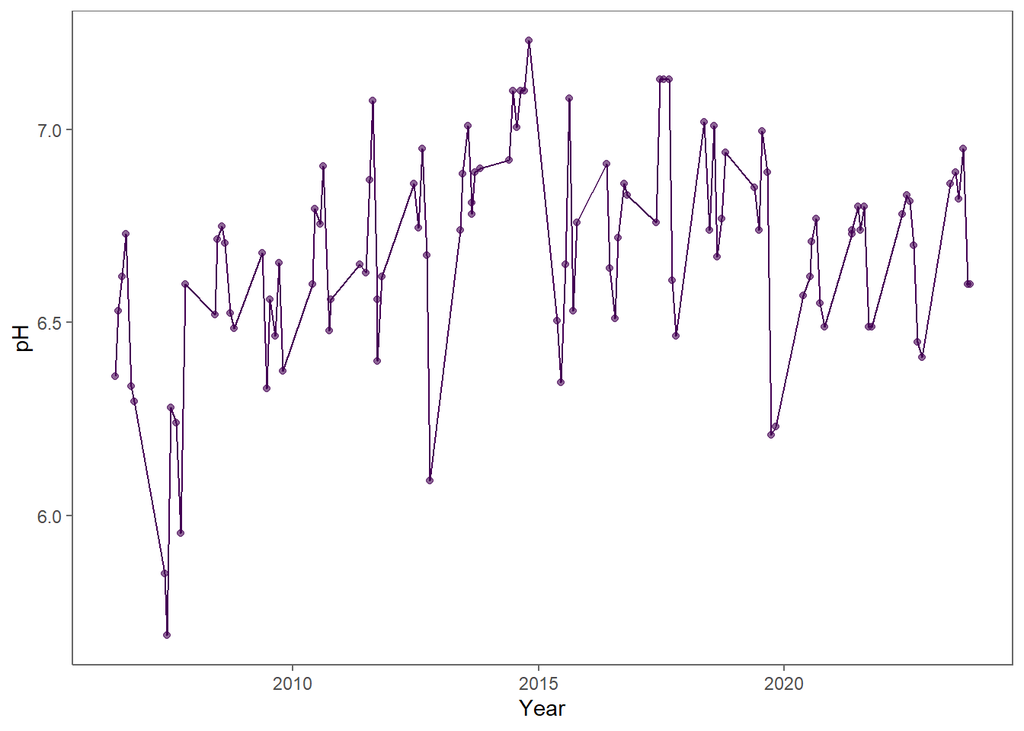

```r
plotTrend(site = "ACEAGL", parameter = "pH", smooth = FALSE)
```

Plot smoothed surface pH for Eagle Lake for all years using default span of 0.3 and by default not including the legend.

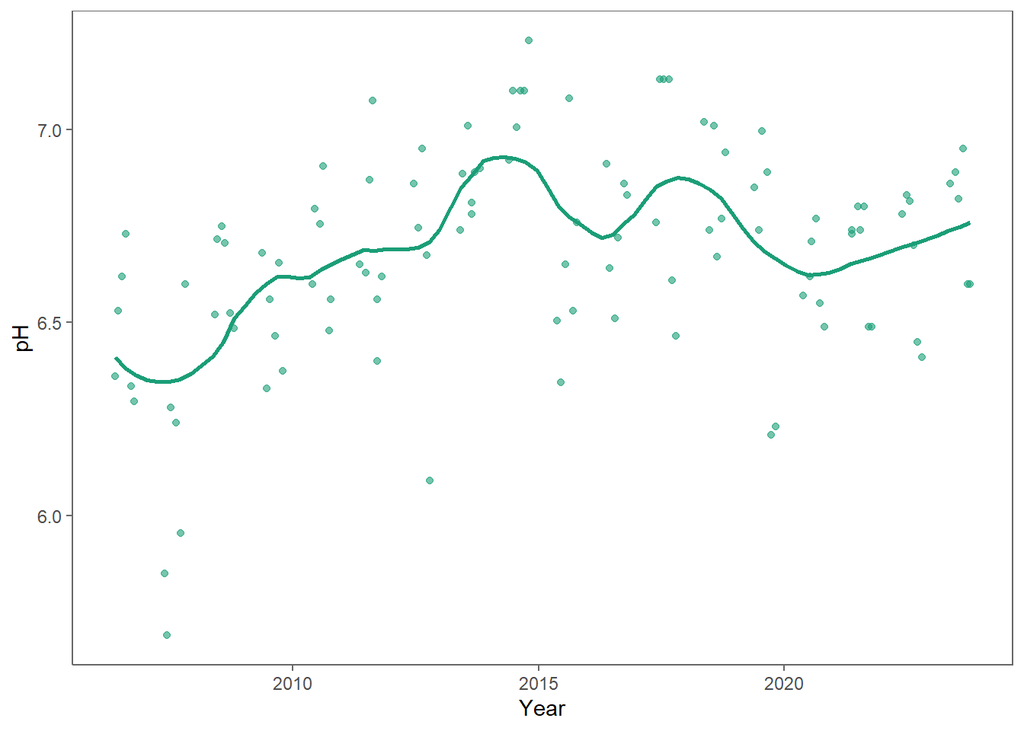

```r
plotTrend(site = "ACEAGL", parameter = "pH", color_theme = 'dark2')
```

Plot smoothed surface pH for Eagle Lake for all years, removing the legend and using span of 0.75.

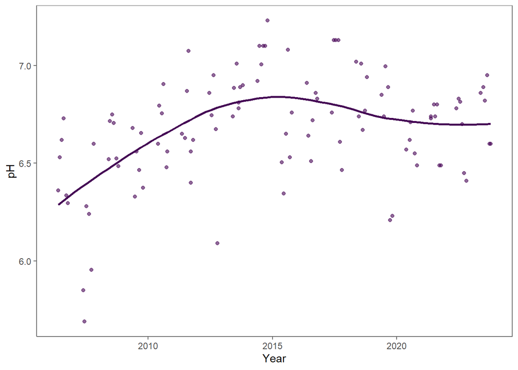

```r
plotTrend(site = "ACEAGL", parameter = "pH", span = 0.75)
```

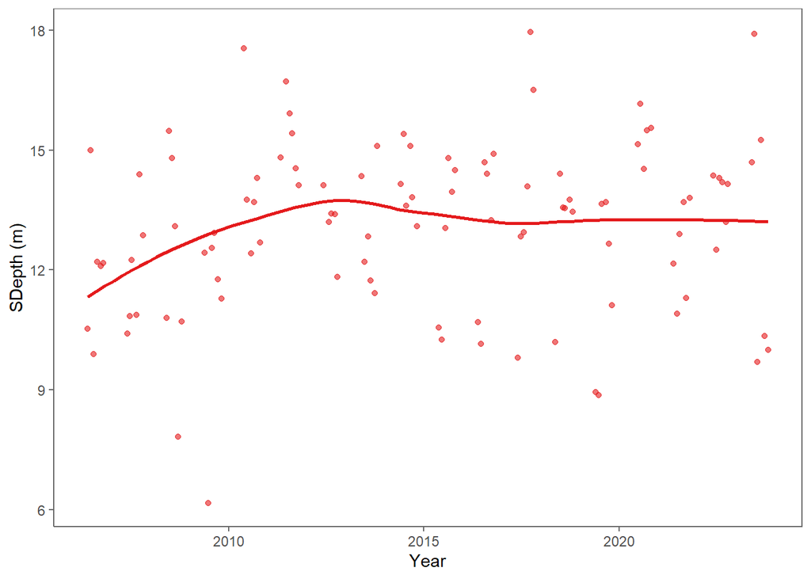

```r
plotTrend(site = "ACJORD", parameter = "SDepth_m",
          span = 0.75, color_theme = 'set1')
```

Plot unsmoothed SO4 in Witch Hole Pond for all years, including censored values.

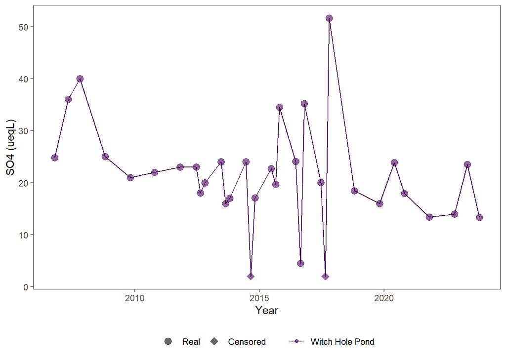

```r
plotTrend(site = "ACWHOL", parameter = "SO4_ueqL",
          smooth = F, include_censored = TRUE, legend_position = 'bottom')
```

Plot unsmoothed line only for pH in Witch Hole Pond for all years.

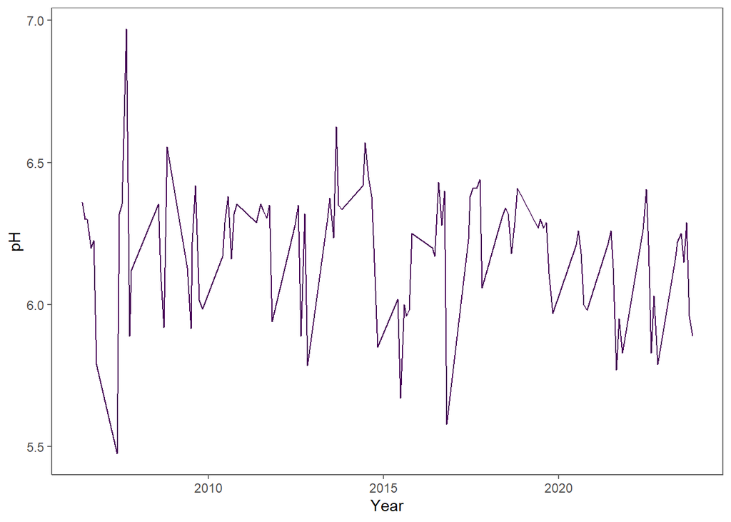

```r
plotTrend(site = "ACWHOL", parameter = "pH", layers = "lines",
          smooth = F, legend_position = 'none')
```

**Multiple sites or params**

Plot smoothed surface pH for active SARA streams over all years with 0.6 span.

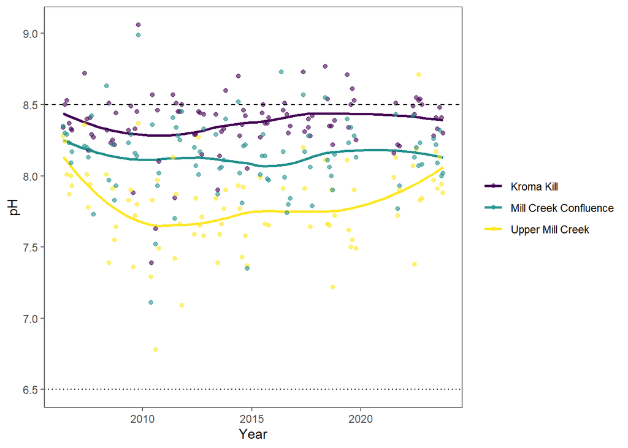

```r
plotTrend(park = "SARA", site = c("SARASA", "SARASC", "SARASD"),
          site_type = "stream", parameter = "pH",
          legend_position = "right", span = 0.6)
```

Plot smoothed surface SO4 for all MIMA streams over all years with 0.6 span.

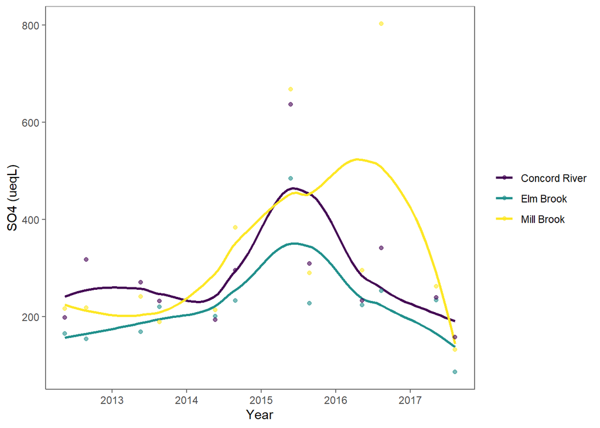

```r
plotTrend(park = "MIMA", site_type = "stream",
          parameter = "SO4_ueqL", legend_position = "right", span = 0.6)
```

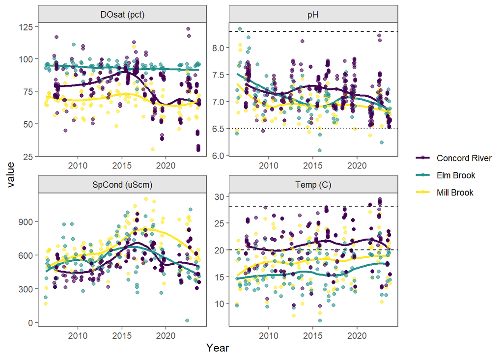

```r
params <- c("Temp_C", "SpCond_uScm", "DOsat_pct", "pH")
plotTrend(park = "MIMA", site_type = "stream",
          parameter = params, legend_position = "right", span = 0.6)
```

Plot smoothed surface Secchi Depth, Penetration Ratio, pH, and DOC in Jordan Pond for all years, including the legend, different color palette, and using span of 0.75.

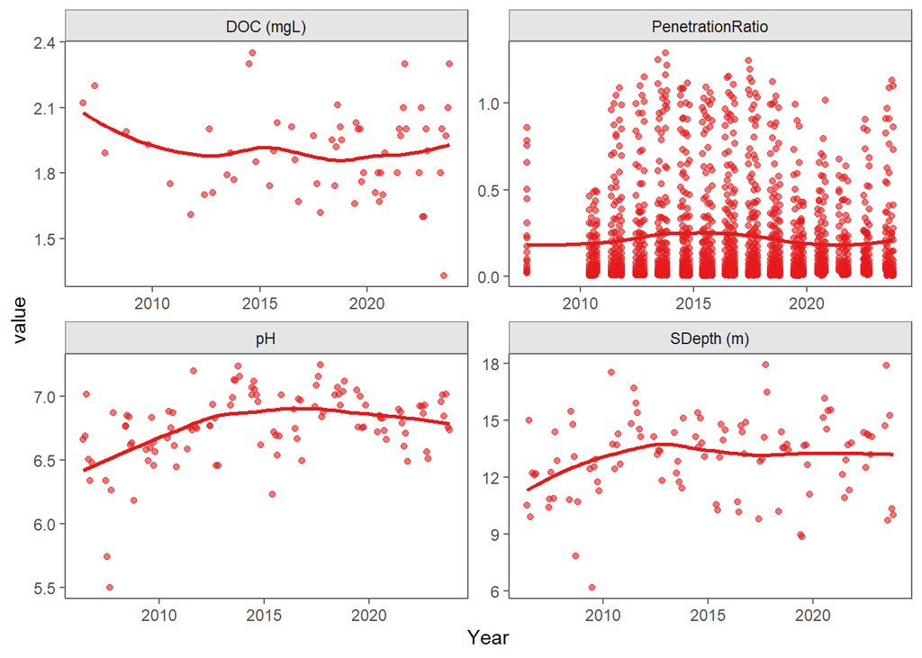

```r
plotTrend(site = "ACJORD", parameter = c("SDepth_m", "PenetrationRatio", "pH", "DOC_mgL"),
          span = 0.75, color_theme = 'set1')
```

Plot smoothed surface water depth in the Pogue for all years, including a different color palette, and using span of 0.75.

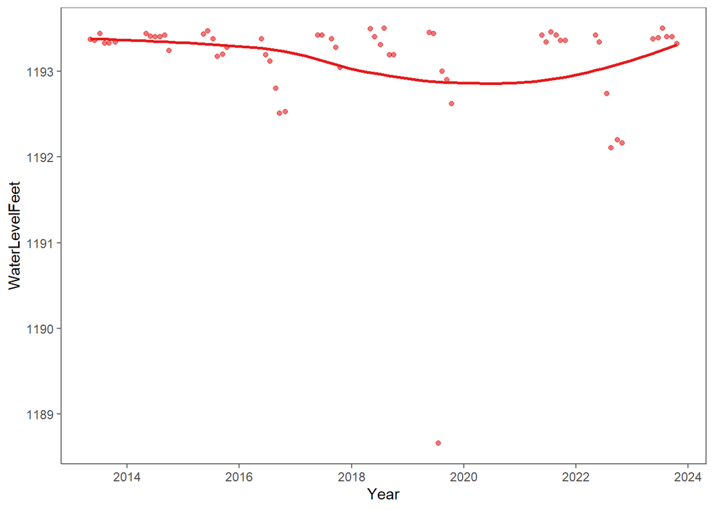

```r
plotTrend(site = "MABIPA", parameter = "WaterLevelFeet", span = 0.75,
          color_theme = 'set1')
```

Plot smoothed TN, TP and SO4 in all MORR sites for all years, including the legend, different color palette, and using span of 0.6. Thresholds, where they exist, plot by default.

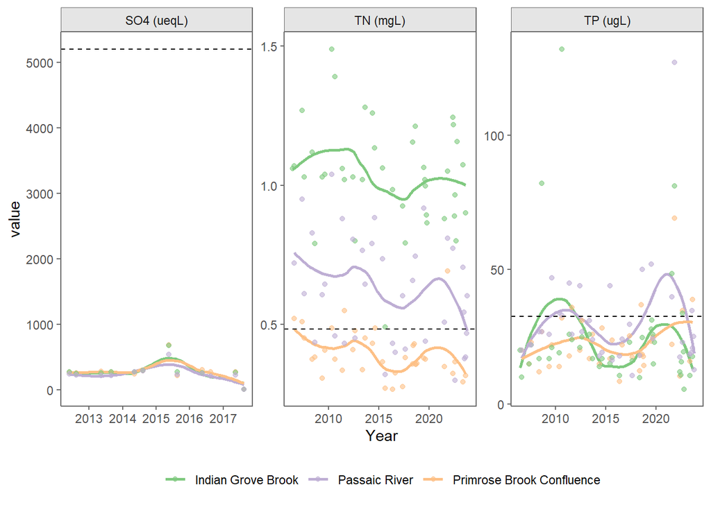

```r
plotTrend(park = "MORR", parameter = c("TN_mgL", "TP_ugL", "SO4_ueqL"),
          span = 0.6, legend_position = 'bottom', color_theme = 'accent')
```

#### plotLakeProfile()

This function produces a heatmap in 1-m bins filtered on park (mostly for ACAD), site, year, month, Sonde in situ parameter and either sample relative to the surface or relative to surface elevation. Can only specify one parameter at a time. If multiple sites or years are selected, plots will be faceted on those factors. Keep options limited for best plotting.

The option to plot relative to surface elevation (eg depth_type = ‘elev’) corrects sample depth for elevation using water level data and datum elevation for that sampling event. The elevation-corrected option allows you to see how the water column is shifting over time, but currently only works for years >= 2013 in ACAD, as water levels prior to that are not in the current data package.

Note that occasionally profiles skip a 1-m bin, which show up as white sections in the plots. Incomplete sampling in 2020 and 2021 also shows up as white sections. If you specify a lake x year x parameter combination that doesn’t exist (e.g., a year a lake isn’t sampled), the function will return an error message instead of an empty plot.

Next step with lake profiles is to model them by day of year, so we can plot a consistent interval between samples, rather than just use the month to plot, like here. This would allow samples taken twice within a month to both be counted, and for early vs. late in the month samples to be corrected for. That will take a bit to figure out…

There are several arguments to customize plots.

- Choose whether to plot the theromocline as points on each profile via `plot_thermocline = TRUE` (default). The thermocline is calculated by rLakeAnalyzer, and is the depth/elevation at which the largest change in temperature occurs in the sampled water column. If no thermocline is detected, as defined by `rLakeAnalyzer::thermo.depth()`, nothing is plotted.
- Choose whether to include only active sites (default) or all sites that have been monitored via `active`.
- Choose color theme. Current enabled themes are ‘spectral’, ‘ryb’ (red - yellow - blue), ‘rb’ (red - blue), and ‘viridis’ (yellow - green - blue). If you prefer other palettes, I can add those too. The only thing I’m trying to avoid is creating the palette manually, since number 1-m bins varies by site and across years. More info on built in ggplot scales can be found here: https://ggplot2-book.org/scales-colour.
- Choose position of legend via `legend_position`. If you don’t want to show the legend, `legend_position = 'none'`.
- Include site name as plot title (title = TRUE). Only enabled when 1 site is selected. Otherwise site names will be in the facets.

**Simple plots**

Plot temperature for Upper Hadlock for years 2013 - 2023 corrected by elevation with thermocline plotted as black circles.

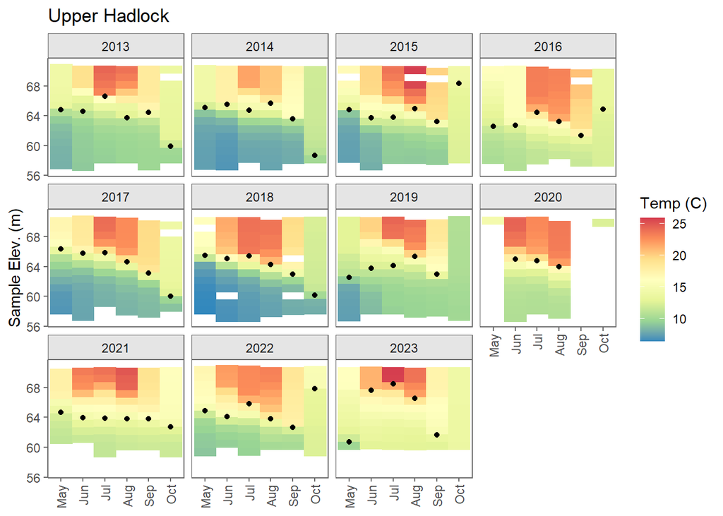

```r
plotLakeProfile(site = "ACUHAD", parameter = "Temp_C", depth_type = 'elev',
                years = 2013:2023)
```

Plot temperature for Eagle Lake for years 2006 - 2023 with raw sample depth, and no plot title or thermocline. Note that I can go back to 2006 because I’m using raw sample depth instead of elevation.

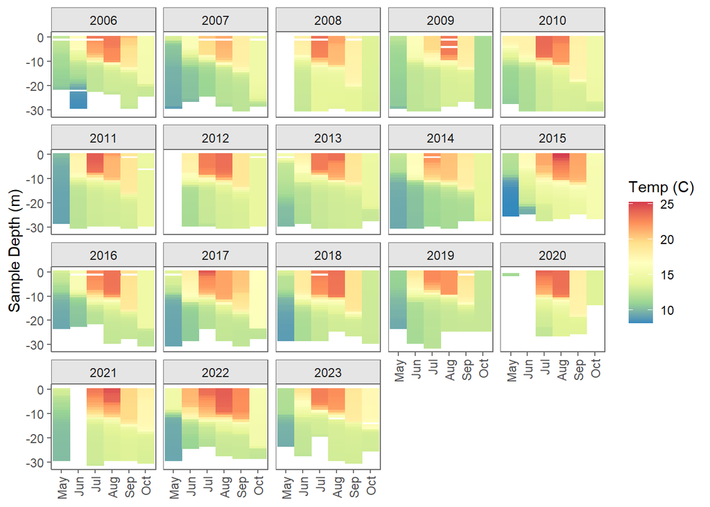

```r
plotLakeProfile(site = "ACEAGL", parameter = "Temp_C", depth_type = 'raw',
                years = 2006:2023, plot_title = FALSE, plot_thermocline = F)
```

Plot temperature for all ACAD lakes sampled in 2023 and raw sample depth.

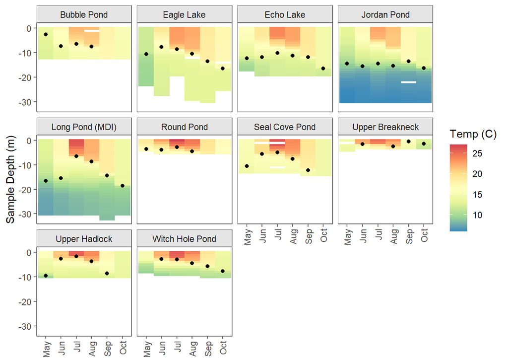

```r
lakes23 <- c("ACBUBL", "ACEAGL", "ACECHO", "ACJORD", "ACLONG", "ACROUN",
             "ACSEAL", "ACUBRK", "ACUHAD", "ACWHOL")
plotLakeProfile(park = "ACAD", site = lakes23, parameter = "Temp_C",
                depth_type = 'raw', years = 2023)
```

Plot DO all ACAD lakes sampled in 2023 and raw sample depth, using reversed ryb palette. Temperature thermocline is also included as black circles.

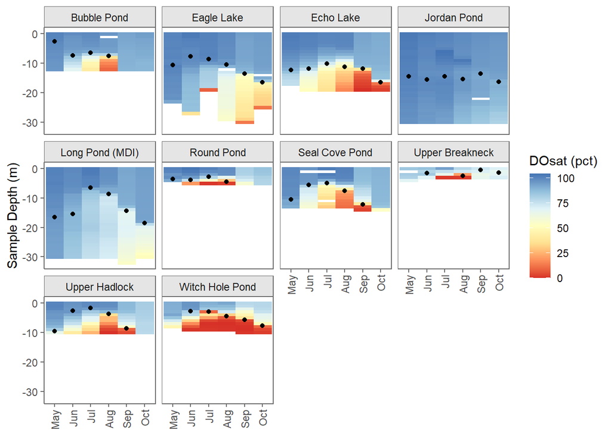

```r
plotLakeProfile(park = "ACAD", site = lakes23,
                parameter = "DOsat_pct", depth_type = 'raw', years = 2023,
                color_theme = 'ryb', color_rev = TRUE)
```

Plot specific conductance for Seal Cove Pond from 2013 to 2023 and sample elevation. Uses spectral palette by default and adds site name as title by default. Thermocline is also plotted as default.

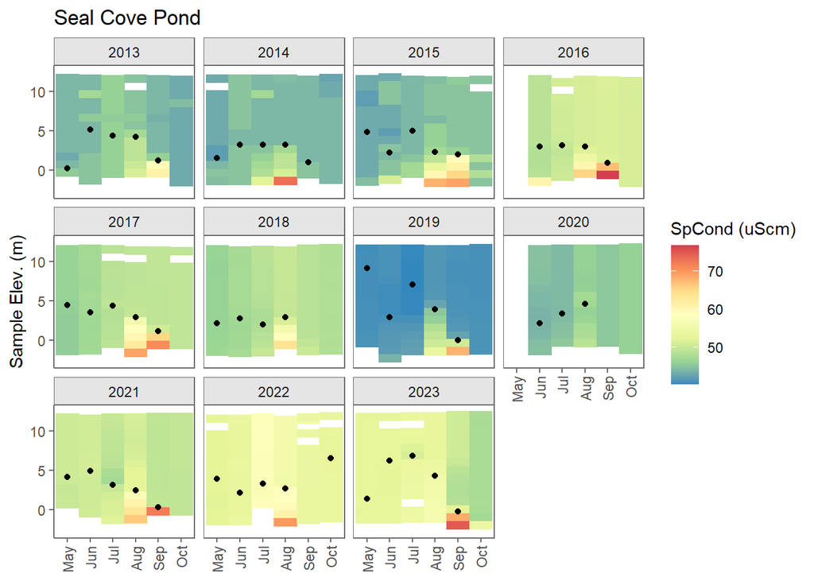

```r
plotLakeProfile(site = "ACSEAL", parameter = "SpCond_uScm",
                depth_type = 'elev', years = 2013:2023)
```

Plot pH for Jordan Pond from 2013 to 2023 and sample elevation, using reversed spectral palette.

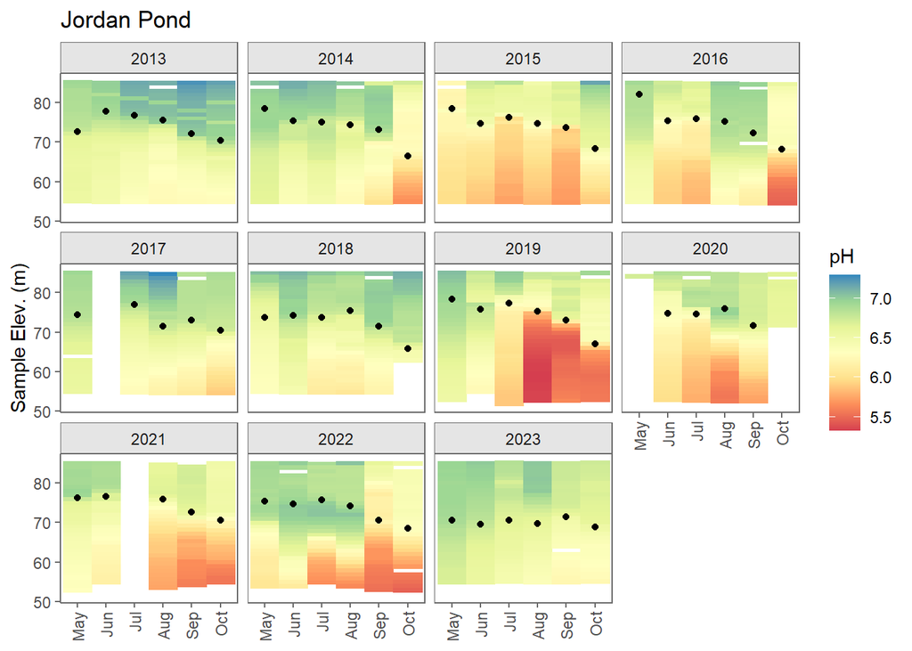

```r
plotLakeProfile(site = "ACJORD", parameter = "pH",
                depth_type = 'elev', years = 2013:2023,
                color_rev = TRUE)
```

Plot pH for all ACAD lakes sampled in 2022 and 2023 and raw sample depth, using reversed ryb palette.

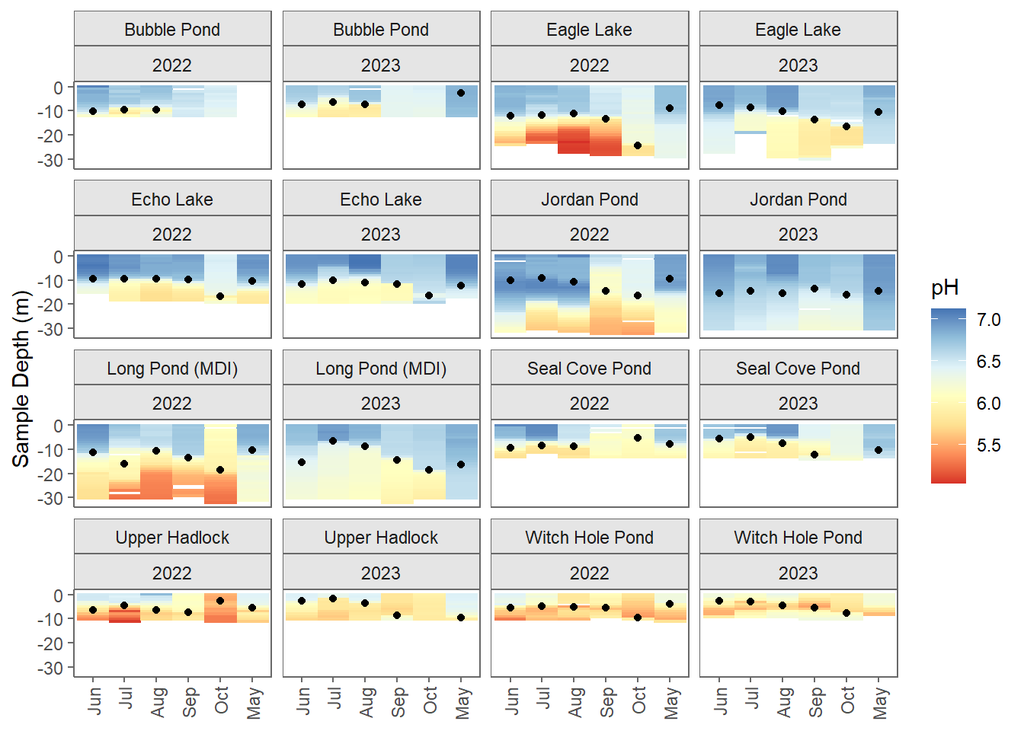

```r
plotLakeProfile(park = "ACAD", site = c("ACBUBL", "ACEAGL", "ACECHO", "ACJORD", "ACLONG", "ACSEAL",
                                        "ACUHAD", "ACWHOL"),
                parameter = "pH", depth_type = 'raw', years = 2022:2023,
                color_theme = 'ryb', color_rev = TRUE)
```

**Combining plots**

Combine plots for temp, DO, pH, and conductance in Bubble Pond for 2023 using the `cowplot` package.

To minimize typing, I define the parameters I wanted at the beginning. This allows you to adjust the parameters once (i.e., change site), and run through the rest of the code without having to edit it. I also only included the plot title on the first figure, and turned it off for the rest.

The `cowplot` package must be installed to use this code. Install the package via `install.packages('cowplot')`. There are other packages to combine plots, including `grid` and `gridExtra`, and the function `ggarrage()` in `ggpubr`. I tend to start with cowplot, because it’s easy to use and has a great [help page](https://wilkelab.org/cowplot/). If I really need to customize a plot (like custom spacing for each plot), then I use `grid/gridExtra`, which allows for more customization, but is a bit harder to work with.

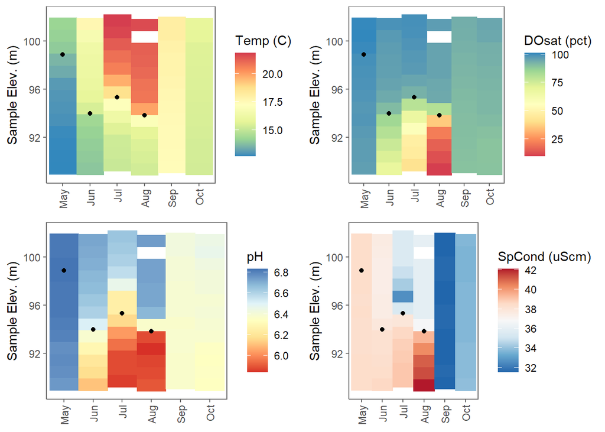

```r
library(cowplot)
sitecode = "ACBUBL"
sitename = getSites(site = sitecode)$SiteName
year = 2023
mon = 5:10
depth = 'elev'
ptitle = F

tplot <- plotLakeProfile(site = sitecode, parameter = "Temp_C", depth_type = depth,
                         years = year, months = mon, plot_title = ptitle)

doplot <- plotLakeProfile(site = sitecode, parameter = "DOsat_pct", depth_type = depth,
                          years = year, months = mon, color_rev = T, plot_title = ptitle)

pHplot <- plotLakeProfile(site = sitecode, parameter = "pH", depth_type = depth,
                          years = year, months = mon, color_theme = "ryb", color_rev = T,
                          plot_title = ptitle)

cnplot <- plotLakeProfile(site = sitecode, parameter = "SpCond_uScm", depth_type = depth,
                         years = year, months = mon, color_theme = 'rb',
                         plot_title = ptitle)

# Default settings
plot_grid(tplot, doplot, pHplot, cnplot)
```

Same plot as above, but customize plot widths, so DO and SpCond have more space for legend, and add title above the grid.

In this case, we’re creating the plot grid with relative widths for each plot. Then we’re combining the title and the plot grid in another grid, setting the title height to be much smaller than the plot grid.

Note that sitename and year are defined in code chunk above.

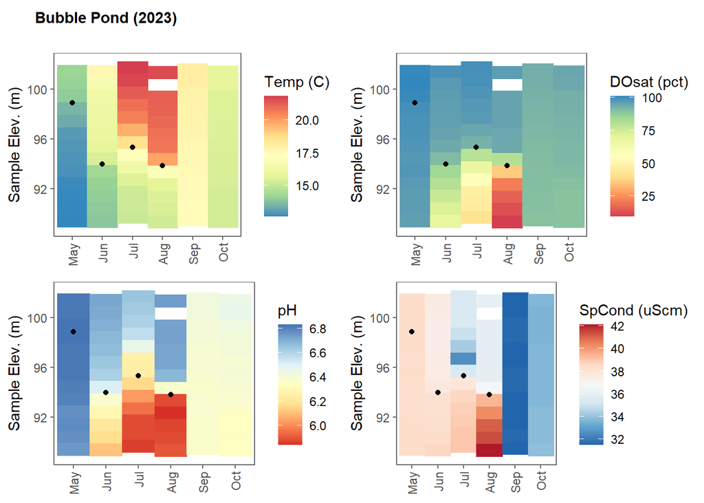

```r
title <- ggdraw() + draw_label(paste0(sitename, " (", year, ")"), size = 11, fontface = 'bold',
                               x = 0.05, hjust = 0, vjust = 0)
pgrid <- plot_grid(tplot, doplot, pHplot, cnplot, rel_widths = c(0.9, 0.95, 0.85, 1)) # doesn't seem to be working
plot_grid(title, pgrid, ncol = 1, rel_heights = c(0.1, 1))
```

#### plotPrecipDischarge()

This function produces a plot with dual y-axes, one for precipitation an done for discharge. The x-axis is date. This function only works for one stream monitoring site at a time. Note that ggplot tends to have a lot of warnings that are hard to suppress, particularly for this plot, which has a daily value for precipitation and only monthly values for discharge. You’re always going to get a message about that by using this function. Function currently only plots years where discharge is collected.

Plot Discharge for Mill Brook in MIMA for past 5 years using default colors.

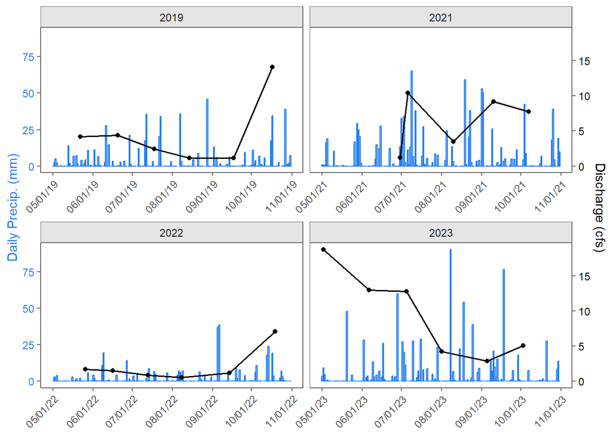

```r
plotPrecipDischarge(site = c("MIMASA"), years = 2019:2023)
```

Plot Discharge for Aunt Betty Inlet and Kebo Stream for 2022 using different colors. Note that this can be slow because has to download precip. data from NADP. LNETN parks download from a faster web service.

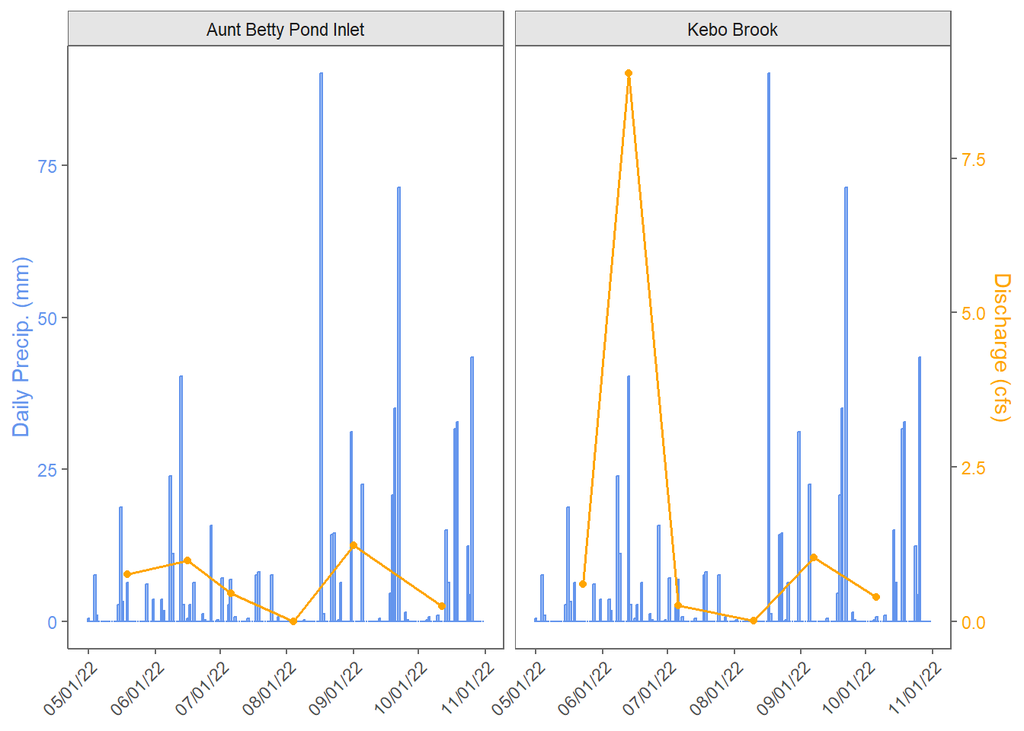

```r
plotPrecipDischarge(site = c("ACABIN", "ACKEBO"), years = 2022, colors = c("cornflowerblue", "orange"))
```

### Summary Functions

#### sumClim30yr()

Summarize 1980 - 2009 30-year normals for all MIMA sites.

```r
mima80 <- sumClim30yr(park = "MIMA", start_year = 1980)
print_head(mima80)
```

| SiteCode | SiteName | UnitCode | SiteLatitude | SiteLongitude | month | mon | ppt_mm | tmax_C | tmin_C | tmean_C |
| --- | --- | --- | --- | --- | --- | --- | --- | --- | --- | --- |
| MIMASA | Mill Brook | MIMA | 42.4628 | -71.35142 | 1 | Jan | 94.5660 | 1.647751 | -9.114256 | 10.76201 |
| MIMASA | Mill Brook | MIMA | 42.4628 | -71.35142 | 2 | Feb | 90.2830 | 3.589302 | -7.698462 | 11.28776 |
| MIMASA | Mill Brook | MIMA | 42.4628 | -71.35142 | 3 | Mar | 113.8927 | 7.937226 | -3.814602 | 11.75183 |
| MIMASA | Mill Brook | MIMA | 42.4628 | -71.35142 | 4 | Apr | 122.3007 | 14.622678 | 2.031678 | 12.59100 |
| MIMASA | Mill Brook | MIMA | 42.4628 | -71.35142 | 5 | May | 104.3247 | 20.599892 | 7.374968 | 13.22492 |
| MIMASA | Mill Brook | MIMA | 42.4628 | -71.35142 | 6 | Jun | 110.2957 | 25.451544 | 12.882056 | 12.56949 |

Summarize 1990 - 2019 30-year normals for Weir Pond.

```r
wefa90 <- sumClim30yr(site = "WEFAPA", start_year = 1990)
print_head(wefa90)
```

| SiteCode | SiteName | UnitCode | SiteLatitude | SiteLongitude | month | mon | ppt_mm | tmax_C | tmin_C | tmean_C |
| --- | --- | --- | --- | --- | --- | --- | --- | --- | --- | --- |
| WEFAPA | Weir Pond | WEFA | 41.25952 | -73.4515 | 1 | Jan | 106.91067 | 2.349197 | -6.699935 | 9.049133 |
| WEFAPA | Weir Pond | WEFA | 41.25952 | -73.4515 | 2 | Feb | 88.55867 | 3.930801 | -6.086426 | 10.017227 |
| WEFAPA | Weir Pond | WEFA | 41.25952 | -73.4515 | 3 | Mar | 123.88433 | 8.218839 | -2.338473 | 10.557312 |
| WEFAPA | Weir Pond | WEFA | 41.25952 | -73.4515 | 4 | Apr | 117.78667 | 15.142444 | 3.387911 | 11.754533 |
| WEFAPA | Weir Pond | WEFA | 41.25952 | -73.4515 | 5 | May | 120.61333 | 20.649505 | 8.809140 | 11.840366 |
| WEFAPA | Weir Pond | WEFA | 41.25952 | -73.4515 | 6 | Jun | 129.48633 | 25.142711 | 14.137722 | 11.004989 |

#### sumClimMonthly()

Note that Daymet data availability are typically not available for the latest year until a few months after the calendar year is over. Weather station data may be available within a day or two of the current date.

Summarize monthly Daymet and weather station data for Mill Brook in MIMA for 2020 to 2023.

```r
mima <- sumClimMonthly(site = "MIMASA", years = 2020:2023, data_type = 'all')
print_head(mima)
```

| SiteCode | SiteName | UnitCode | year | month | mon | SiteLatitude | dm_ppt_mm | dm_tmax_C | dm_tmin_C | dm_tmean_C | dm_srad | dm_PEThar | dm_BAL | dm_SPEI01 | dm_SPEI03 | ws_ppt_mm | ws_tmax_C | ws_tmin_C | ws_tmean_C |
| --- | --- | --- | --- | --- | --- | --- | --- | --- | --- | --- | --- | --- | --- | --- | --- | --- | --- | --- | --- |
| MIMASA | Mill Brook | MIMA | 2020 | 1 | Jan | 42.4628 | 40.10 | 5.519000 | -3.9876667 | 9.506667 | 6.309981 | 9.801476 | 30.298524 | -1.0450132 | NA | 35.052 | 5.645161 | -4.1757097 | 9.820871 |
| MIMASA | Mill Brook | MIMA | 2020 | 2 | Feb | 42.4628 | 75.32 | 5.892069 | -4.2696552 | 10.161724 | 8.808572 | 12.621261 | 62.698739 | -0.1048146 | NA | 67.818 | 5.843000 | -4.4444828 | 10.287483 |
| MIMASA | Mill Brook | MIMA | 2020 | 3 | Mar | 42.4628 | 85.42 | 11.125484 | -0.7348387 | 11.860323 | 13.144209 | 29.285872 | 56.134128 | 0.2888851 | -0.6121967 | 78.232 | 11.559032 | -0.3942903 | 11.953323 |
| MIMASA | Mill Brook | MIMA | 2020 | 4 | Apr | 42.4628 | 125.65 | 12.097000 | 1.6963333 | 10.400667 | 16.928311 | 33.771117 | 91.878883 | 0.8453497 | 0.8893334 | 116.840 | 12.314833 | 1.9258667 | 10.388967 |
| MIMASA | Mill Brook | MIMA | 2020 | 5 | May | 42.4628 | 54.77 | 20.869677 | 7.6758065 | 13.193871 | 22.044220 | 77.376748 | -22.606748 | -0.2099808 | -0.5765069 | 41.148 | 21.057387 | 7.4552581 | 13.602129 |
| MIMASA | Mill Brook | MIMA | 2020 | 6 | Jun | 42.4628 | 83.76 | 27.664000 | 13.8480000 | 13.816000 | 21.398882 | 89.168981 | -5.408981 | 0.6017560 | -0.6082534 | 42.926 | 27.796233 | 13.7036667 | 14.092567 |

Summarize monthly weather station data for the Pogue for 2024.

```r
pogwstn <- sumClimMonthly(site = "MABIPA", years = 2024, data_type = 'wstn')
print_head(pogwstn)
```

| SiteCode | SiteName | UnitCode | year | month | mon | ws_ppt_mm | ws_tmax_C | ws_tmin_C | ws_tmean_C |
| --- | --- | --- | --- | --- | --- | --- | --- | --- | --- |
| MABIPA | The Pogue | MABI | 2024 | 1 | Jan | 138.684 | 0.3942903 | -8.620032 | 9.014323 |
| MABIPA | The Pogue | MABI | 2024 | 2 | Feb | 7.874 | 4.0612414 | -8.678207 | 12.739448 |
| MABIPA | The Pogue | MABI | 2024 | 3 | Mar | 183.896 | 7.1505806 | -3.799323 | 10.949903 |
| MABIPA | The Pogue | MABI | 2024 | 4 | Apr | 101.346 | 13.4073667 | 0.388900 | 13.018467 |
| MABIPA | The Pogue | MABI | 2024 | 5 | May | 44.196 | 17.4358462 | 7.008769 | 10.427077 |
| MABIPA | The Pogue | MABI | 2024 | 6 | Jun | 0.000 | NaN | NaN | NaN |